# Unsupervised Learning in Action: Discovering Patterns Without Labels

Autor: DATAMANZ

Octubre 2024

# Section 1 - *Hawks*

The exercises will be based on the *Hawks* dataset from the R package *Stat2Data*.

Students and faculty at **Cornell College** in **Mount Vernon, Iowa**, collected data over many years at the **Lake MacBride Hawk Watch**, near **Iowa City, Iowa**. The dataset analyzed here is a **subset** of the original dataset, including only species with **more than 10 observations**. The data were collected from **random samples** of three different hawk species: **Red-tailed Hawk, Sharp-shinned Hawk, and Cooper’s Hawk**.

We selected this dataset due to its **similarity to the *penguins* dataset** and its **potential for applying unsupervised data mining algorithms**.

```r
if (!require('Stat2Data')) install.packages('Stat2Data')
library(Stat2Data)
data("Hawks")
summary(Hawks)
```

```
##      Month             Day             Year       CaptureTime   ReleaseTime
##  Min.   : 8.000   Min.   : 1.00   Min.   :1992   11:35  : 14          :842
##  1st Qu.: 9.000   1st Qu.: 9.00   1st Qu.:1995   13:30  : 14   11:00  :  2
##  Median :10.000   Median :16.00   Median :1999   11:45  : 13   11:35  :  2
##  Mean   : 9.843   Mean   :15.74   Mean   :1998   12:10  : 13   12:05  :  2
##  3rd Qu.:10.000   3rd Qu.:23.00   3rd Qu.:2001   14:00  : 13   12:50  :  2
##  Max.   :11.000   Max.   :31.00   Max.   :2003   13:05  : 12   13:32  :  2
##                                                  (Other):829   (Other): 56
##       BandNumber  Species  Age     Sex          Wing           Weight
##            :  2   CH: 70   A:224    :576   Min.   : 37.2   Min.   :  56.0
##  1142-09240:  1   RT:577   I:684   F:174   1st Qu.:202.0   1st Qu.: 185.0
##  1142-09241:  1   SS:261           M:158   Median :370.0   Median : 970.0
##  1142-09242:  1                            Mean   :315.6   Mean   : 772.1
##  1142-18229:  1                            3rd Qu.:390.0   3rd Qu.:1120.0
##  1142-19209:  1                            Max.   :480.0   Max.   :2030.0
##  (Other)   :901                            NA's   :1       NA's   :10
##      Culmen         Hallux            Tail        StandardTail
##  Min.   : 8.6   Min.   :  9.50   Min.   :119.0   Min.   :115.0
##  1st Qu.:12.8   1st Qu.: 15.10   1st Qu.:160.0   1st Qu.:162.0
##  Median :25.5   Median : 29.40   Median :214.0   Median :215.0
##  Mean   :21.8   Mean   : 26.41   Mean   :198.8   Mean   :199.2
##  3rd Qu.:27.3   3rd Qu.: 31.40   3rd Qu.:225.0   3rd Qu.:226.0
##  Max.   :39.2   Max.   :341.40   Max.   :288.0   Max.   :335.0
##  NA's   :7      NA's   :6                        NA's   :337
##      Tarsus        WingPitFat        KeelFat           Crop
##  Min.   :24.70   Min.   :0.0000   Min.   :0.000   Min.   :0.0000
##  1st Qu.:55.60   1st Qu.:0.0000   1st Qu.:2.000   1st Qu.:0.0000
##  Median :79.30   Median :1.0000   Median :2.000   Median :0.0000
##  Mean   :71.95   Mean   :0.7922   Mean   :2.184   Mean   :0.2345
##  3rd Qu.:87.00   3rd Qu.:1.0000   3rd Qu.:3.000   3rd Qu.:0.2500
##  Max.   :94.00   Max.   :3.0000   Max.   :4.000   Max.   :5.0000
##  NA's   :833     NA's   :831      NA's   :341     NA's   :343
```

## Data Cleaning

Present the dataset, including the **column names and their meanings**, as well as the **distributions of their values**.

We start by **loading the necessary libraries** for our analysis.

```r
if (!require('cluster')) install.packages('cluster')
library(cluster)
if (!require('Stat2Data')) install.packages('Stat2Data')
library(Stat2Data)
if (!require('Stat2Data')) install.packages('Stat2Data')
if (!require('dplyr')) install.packages('dplyr')
```

```r
library(dplyr)
if (!require('ggplot2')) install.packages("ggplot2")
library(ggplot2)
if (!require('factoextra')) install.packages("factoextra")
library(factoextra)
if (!require('NbClust')) install.packages("NbClust")
library(NbClust)
if (!require('dbscan')) install.packages('dbscan')
library(dbscan)
if (!require('tidyr')) install.packages('tidyr')
library(tidyr)
```

We perform a **comprehensive summary** to examine all variables in the dataset, including their **quartiles**.

This **initial analysis** is an essential **preliminary step** that is highly beneficial when working with datasets. By conducting this review, we can gain **an overview of the data distribution**, **identify potential anomalies**, and **better understand the dataset’s underlying structure**.

This allows us to make **informed decisions** in the subsequent steps.

```r
data("Hawks")
summary(Hawks)
```

```
##      Month             Day             Year       CaptureTime   ReleaseTime
##  Min.   : 8.000   Min.   : 1.00   Min.   :1992   11:35  : 14          :842
##  1st Qu.: 9.000   1st Qu.: 9.00   1st Qu.:1995   13:30  : 14   11:00  :  2
##  Median :10.000   Median :16.00   Median :1999   11:45  : 13   11:35  :  2
##  Mean   : 9.843   Mean   :15.74   Mean   :1998   12:10  : 13   12:05  :  2
##  3rd Qu.:10.000   3rd Qu.:23.00   3rd Qu.:2001   14:00  : 13   12:50  :  2
##  Max.   :11.000   Max.   :31.00   Max.   :2003   13:05  : 12   13:32  :  2
##                                                  (Other):829   (Other): 56
##       BandNumber  Species  Age     Sex          Wing           Weight
##            :  2   CH: 70   A:224    :576   Min.   : 37.2   Min.   :  56.0
##  1142-09240:  1   RT:577   I:684   F:174   1st Qu.:202.0   1st Qu.: 185.0
##  1142-09241:  1   SS:261           M:158   Median :370.0   Median : 970.0
##  1142-09242:  1                            Mean   :315.6   Mean   : 772.1
##  1142-18229:  1                            3rd Qu.:390.0   3rd Qu.:1120.0
##  1142-19209:  1                            Max.   :480.0   Max.   :2030.0
##  (Other)   :901                            NA's   :1       NA's   :10
##      Culmen         Hallux            Tail        StandardTail
##  Min.   : 8.6   Min.   :  9.50   Min.   :119.0   Min.   :115.0
##  1st Qu.:12.8   1st Qu.: 15.10   1st Qu.:160.0   1st Qu.:162.0
##  Median :25.5   Median : 29.40   Median :214.0   Median :215.0
##  Mean   :21.8   Mean   : 26.41   Mean   :198.8   Mean   :199.2
##  3rd Qu.:27.3   3rd Qu.: 31.40   3rd Qu.:225.0   3rd Qu.:226.0
##  Max.   :39.2   Max.   :341.40   Max.   :288.0   Max.   :335.0
##  NA's   :7      NA's   :6                        NA's   :337
##      Tarsus        WingPitFat        KeelFat           Crop
##  Min.   :24.70   Min.   :0.0000   Min.   :0.000   Min.   :0.0000
##  1st Qu.:55.60   1st Qu.:0.0000   1st Qu.:2.000   1st Qu.:0.0000
##  Median :79.30   Median :1.0000   Median :2.000   Median :0.0000
##  Mean   :71.95   Mean   :0.7922   Mean   :2.184   Mean   :0.2345
##  3rd Qu.:87.00   3rd Qu.:1.0000   3rd Qu.:3.000   3rd Qu.:0.2500
##  Max.   :94.00   Max.   :3.0000   Max.   :4.000   Max.   :5.0000
##  NA's   :833     NA's   :831      NA's   :341     NA's   :343
```

We observe that we will be working with **measurements of various characteristics of hawks** that have been **captured and released**.

In our dataset, we have **several numerical variables**, such as **wing length** and **weight**.

To better understand the **structure of our dataset**, we use the **str** function.

```r
str(Hawks)
```

```
## 'data.frame':    908 obs. of  19 variables:
##  $ Month       : int  9 9 9 9 9 9 9 9 9 9 ...
##  $ Day         : int  19 22 23 23 27 28 28 29 29 30 ...
##  $ Year        : int  1992 1992 1992 1992 1992 1992 1992 1992 1992 1992 ...
##  $ CaptureTime : Factor w/ 308 levels " ","1:15","1:31",..: 181 25 138 42 62 71 181 88 261 192 ...
##  $ ReleaseTime : Factor w/ 60 levels ""," ","10:20",..: 1 2 2 2 2 2 2 2 2 2 ...
##  $ BandNumber  : Factor w/ 907 levels " ","1142-09240",..: 856 857 858 809 437 280 859 860 861 281 ...
##  $ Species     : Factor w/ 3 levels "CH","RT","SS": 2 2 2 1 3 2 2 2 2 2 ...
##  $ Age         : Factor w/ 2 levels "A","I": 2 2 2 2 2 2 2 1 1 2 ...
##  $ Sex         : Factor w/ 3 levels "","F","M": 1 1 1 2 2 1 1 1 1 1 ...
##  $ Wing        : num  385 376 381 265 205 412 370 375 412 405 ...
##  $ Weight      : int  920 930 990 470 170 1090 960 855 1210 1120 ...
##  $ Culmen      : num  25.7 NA 26.7 18.7 12.5 28.5 25.3 27.2 29.3 26 ...
##  $ Hallux      : num  30.1 NA 31.3 23.5 14.3 32.2 30.1 30 31.3 30.2 ...
##  $ Tail        : int  219 221 235 220 157 230 212 243 210 238 ...
##  $ StandardTail: int  NA NA NA NA NA NA NA NA NA NA ...
##  $ Tarsus      : num  NA NA NA NA NA NA NA NA NA NA ...
##  $ WingPitFat  : int  NA NA NA NA NA NA NA NA NA NA ...
##  $ KeelFat     : num  NA NA NA NA NA NA NA NA NA NA ...
##  $ Crop        : num  NA NA NA NA NA NA NA NA NA NA ...
```

For our analysis, we use the **dataset documentation** available at  
[*https://rdrr.io/rforge/Stat2Data/man/Hawks.html*](https://rdrr.io/rforge/Stat2Data/man/Hawks.html).

This source provides **detailed and specific information** about the **attributes** present in the dataset.

### Variable Descriptions:

- **Month**: Capture month code, where **8 = September** and **12 = December**.
- **Day**: Day of the month when the hawk was captured.
- **Year**: Capture year, ranging from **1992 to 2003**.
- **CaptureTime**: Time of capture in **HH** format.
- **ReleaseTime**: Time of release in **HH** format.
- **BandNumber**: **ID band code** assigned to the bird.
- **Species**: Bird species:
  - **CH** = Cooper’s Hawk
  - **RT** = Red-tailed Hawk
  - **SS** = Sharp-shinned Hawk
- **Age**: Age of the bird:
  - **A** = Adult
  - **I** = Immature
- **Sex**: Sex of the bird:
  - **F** = Female
  - **M** = Male
  - Missing values indicate **unknown sex**.
- **Wing**: **Primary wing feather length (mm)**, measured from tip to wrist.
- **Weight**: **Body weight (grams)**.
- **Culmen**: **Upper bill length (mm)**, measured from tip to the fleshy part.
- **Hallux**: **Killing talon length (mm)**.
- **Tail**: **Tail length measurement (mm)** (MacBride Raptor Center method).
- **StandardTail**: **Standard tail length measurement (mm)**.
- **Tarsus**: **Basic foot bone length (mm)**.
- **WingPitFat**: **Amount of fat in the wing pit**.
- **KeelFat**: **Amount of fat on the breastbone** (measured by touch).
- **Crop**: **Food content in the crop**, coded **1 = full** to **0 = empty**.

Now, we continue **preparing the dataset** by **searching for missing values**.

```r
missing_values <- colSums(is.na(Hawks))
print(missing_values)
```

```
##        Month          Day         Year  CaptureTime  ReleaseTime   BandNumber
##            0            0            0            0            0            0
##      Species          Age          Sex         Wing       Weight       Culmen
##            0            0            0            1           10            7
##       Hallux         Tail StandardTail       Tarsus   WingPitFat      KeelFat
##            6            0          337          833          831          341
##         Crop
##          343
```

We begin **cleaning the dataset**.

Afterward, we **check for missing values again**.

```r
limpio_hawks <- Hawks[, !(names(Hawks) %in% c("StandardTail", "Tarsus", "WingPitFat", "KeelFat", "Crop"))]
missing_values2 <- colSums(is.na(limpio_hawks))
print(missing_values2)
```

```
##       Month         Day        Year CaptureTime ReleaseTime  BandNumber
##           0           0           0           0           0           0
##     Species         Age         Sex        Wing      Weight      Culmen
##           0           0           0           1          10           7
##      Hallux        Tail
##           6           0
```

The number of **missing values has significantly decreased**.

Currently, the missing values are:  
- **Wing**: **1** missing value  
- **Weight**: **10** missing values  
- **Culmen**: **7** missing values  
- **Hallux**: **6** missing values

Following the **methodology**, we will attempt to **impute these values** to obtain a **fully clean dataset**.

We will start with the **Wing** variable, using **mean values based on age and species**.

We chose this attribute first since it only has **one missing value**, making it easier to apply the same method to the other variables.

### First, we calculate the mean values based on species and age.

```r
mean_wing <- Hawks %>%
  group_by(Species, Age) %>%
  summarise(mean_wing = mean(Wing, na.rm = TRUE), .groups = 'drop')

print(mean_wing)
```

```
## # A tibble: 6 × 3
##   Species Age   mean_wing
##   <fct>   <fct>     <dbl>
## 1 CH      A          242.
## 2 CH      I          246.
## 3 RT      A          386.
## 4 RT      I          383.
## 5 SS      A          186.
## 6 SS      I          185.
```

We identify the **row corresponding to the NA value** in the **Wing** attribute that we need to replace.

```r
na_wing_row <- Hawks[is.na(Hawks$Wing), ]
print(na_wing_row)
```

```
##     Month Day Year CaptureTime ReleaseTime BandNumber Species Age Sex Wing
## 263    10  15 1995       14:20                             CH   A       NA
##     Weight Culmen Hallux Tail StandardTail Tarsus WingPitFat KeelFat Crop
## 263    480   17.7   32.1  198           NA     NA         NA      NA   NA
```

We impute the value **242.4839** to the missing value in the **Wing** attribute.

```r
Hawks <- Hawks %>%
  mutate(Wing = ifelse(is.na(Wing), 242.4839, Wing))
```

Now, we **merge the imputed values** back into the **original dataset** to ensure data consistency.

We apply this **imputation process** to **all variables with missing values**.

```r
mean_values <- Hawks %>%
  group_by(Species, Age) %>%
  summarise(
    mean_wing = mean(Wing, na.rm = TRUE),
    mean_weight = mean(Weight, na.rm = TRUE),
    mean_culmen = mean(Culmen, na.rm = TRUE),
    mean_hallux = mean(Hallux, na.rm = TRUE),
    .groups = 'drop'
  )

print("Medias calculadas por especie y edad:")
```

```
## [1] "Medias calculadas por especie y edad:"
```

```r
print(mean_values)
```

```
## # A tibble: 6 × 6
##   Species Age   mean_wing mean_weight mean_culmen mean_hallux
##   <fct>   <fct>     <dbl>       <dbl>       <dbl>       <dbl>
## 1 CH      A          242.        450.        18.0        23.9
## 2 CH      I          246.        395.        17.2        21.9
## 3 RT      A          386.       1161.        27.5        31.1
## 4 RT      I          383.       1076.        26.8        32.2
## 5 SS      A          186.        150.        11.7        16.9
## 6 SS      I          185.        147.        11.4        14.2
```

With the **mean values calculated for all attributes** of our missing variables, we **impute them** just as we initially did with **Wing**, but now for the **other three variables**.

As a result, we **no longer have missing data** (except in the **original variables**, which we will remove in the next step).

```r
Hawks <- Hawks %>%
  left_join(mean_values, by = c("Species", "Age")) %>%
  mutate(
    Wing = ifelse(is.na(Wing), mean_wing, Wing),
    Weight = ifelse(is.na(Weight), mean_weight, Weight),
    Culmen = ifelse(is.na(Culmen), mean_culmen, Culmen),
    Hallux = ifelse(is.na(Hallux), mean_hallux, Hallux)
  ) %>%
  select(-mean_wing, -mean_weight, -mean_culmen, -mean_hallux)

missing_values_after_imputation <- colSums(is.na(Hawks))
print("Valores faltantes después de la imputación:")
```

```
## [1] "Valores faltantes después de la imputación:"
```

```r
print(missing_values_after_imputation)
```

```
##        Month          Day         Year  CaptureTime  ReleaseTime   BandNumber
##            0            0            0            0            0            0
##      Species          Age          Sex         Wing       Weight       Culmen
##            0            0            0            0            0            0
##       Hallux         Tail StandardTail       Tarsus   WingPitFat      KeelFat
##            0            0          337          833          831          341
##         Crop
##          343
```

We obtain our **clean dataset**, with **no missing values**, all **imputations applied**, and **unnecessary variables removed**.

```r
hawks_limpio2 <- Hawks[, !(names(Hawks) %in% c("StandardTail", "Tarsus", "WingPitFat", "KeelFat", "Crop"))]
missing_values3 <- colSums(is.na(hawks_limpio2))
print(missing_values3)
```

```
##       Month         Day        Year CaptureTime ReleaseTime  BandNumber
##           0           0           0           0           0           0
##     Species         Age         Sex        Wing      Weight      Culmen
##           0           0           0           0           0           0
##      Hallux        Tail
##           0           0
```

We perform a **new summary** of our **clean dataset** and reanalyze the variables to conduct an **initial exploratory analysis**.

```r
summary(hawks_limpio2)
```

```
##      Month             Day             Year       CaptureTime   ReleaseTime
##  Min.   : 8.000   Min.   : 1.00   Min.   :1992   11:35  : 14          :842
##  1st Qu.: 9.000   1st Qu.: 9.00   1st Qu.:1995   13:30  : 14   11:00  :  2
##  Median :10.000   Median :16.00   Median :1999   11:45  : 13   11:35  :  2
##  Mean   : 9.843   Mean   :15.74   Mean   :1998   12:10  : 13   12:05  :  2
##  3rd Qu.:10.000   3rd Qu.:23.00   3rd Qu.:2001   14:00  : 13   12:50  :  2
##  Max.   :11.000   Max.   :31.00   Max.   :2003   13:05  : 12   13:32  :  2
##                                                  (Other):829   (Other): 56
##       BandNumber  Species  Age     Sex          Wing           Weight
##            :  2   CH: 70   A:224    :576   Min.   : 37.2   Min.   :  56.0
##  1142-09240:  1   RT:577   I:684   F:174   1st Qu.:202.0   1st Qu.: 185.0
##  1142-09241:  1   SS:261           M:158   Median :370.0   Median : 970.0
##  1142-09242:  1                            Mean   :315.6   Mean   : 770.5
##  1142-18229:  1                            3rd Qu.:390.0   3rd Qu.:1120.0
##  1142-19209:  1                            Max.   :480.0   Max.   :2030.0
##  (Other)   :901
##      Culmen          Hallux            Tail
##  Min.   : 8.60   Min.   :  9.50   Min.   :119.0
##  1st Qu.:12.78   1st Qu.: 15.07   1st Qu.:160.0
##  Median :25.50   Median : 29.40   Median :214.0
##  Mean   :21.79   Mean   : 26.39   Mean   :198.8
##  3rd Qu.:27.30   3rd Qu.: 31.40   3rd Qu.:225.0
##  Max.   :39.20   Max.   :341.40   Max.   :288.0
##
```

At first glance, we can determine that the **Weight** variable shows a **significant difference** between the minimum and maximum values.

We calculate the **standard deviation** of the **Weight** variable to determine if there are **outliers**.

```r
detect_outliers_sd <- function(data, column) {
  mean_value <- mean(data[[column]], na.rm = TRUE)
  sd_value <- sd(data[[column]], na.rm = TRUE)

  lower_bound <- mean_value - 3 * sd_value
  upper_bound <- mean_value + 3 * sd_value

  outliers <- data %>% filter(data[[column]] < lower_bound | data[[column]] > upper_bound)

  return(list(outliers = outliers, lower_bound = lower_bound, upper_bound = upper_bound))
}

result <- detect_outliers_sd(hawks_limpio2, "Weight")
outliers_weight_sd <- result$outliers
lower_bound <- result$lower_bound
upper_bound <- result$upper_bound

print("Outliers in the 'Weight' column using standard deviation:")
```

```
## [1] "Outliers in the 'Weight' column using standard deviation:"
```

```r
print(outliers_weight_sd)
```

```
##  [1] Month       Day         Year        CaptureTime ReleaseTime BandNumber
##  [7] Species     Age         Sex         Wing        Weight      Culmen
## [13] Hallux      Tail
## <0 rows> (o 0- extensión row.names)
```

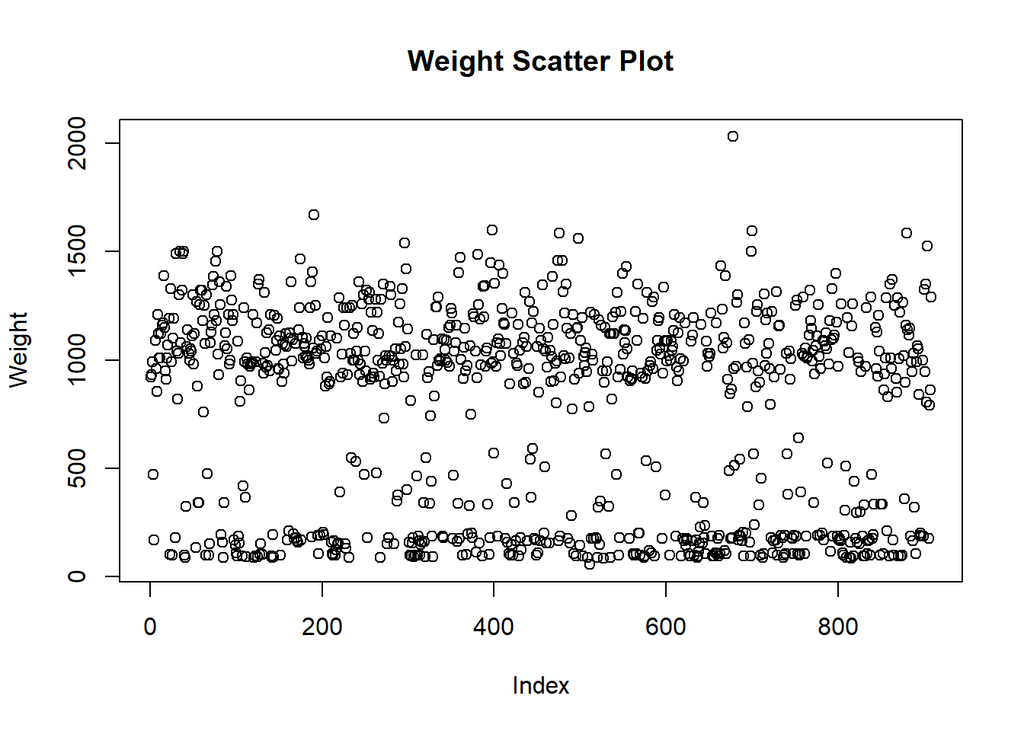

```r
plot(hawks_limpio2$Weight,
     main = "Weight Scatter Plot",
     ylab = "Weight",
     xlab = "Index",
     pch = ifelse(hawks_limpio2$Weight < lower_bound | hawks_limpio2$Weight > upper_bound, 19, 1),
     col = ifelse(hawks_limpio2$Weight < lower_bound | hawks_limpio2$Weight > upper_bound, "red", "black"))

abline(h = c(lower_bound, upper_bound), col = "blue", lwd = 2, lty = 2)
```

We perform a **second outlier analysis** on **foot size measurements**, as the **summary statistics** indicate a **significant difference** between the **minimum and maximum values**.

This time, we **observe 7 outliers**.

```r
detect_outliers_sd <- function(data, column) {
  mean_value <- mean(data[[column]], na.rm = TRUE)
  sd_value <- sd(data[[column]], na.rm = TRUE)

  lower_bound <- mean_value - 3 * sd_value
  upper_bound <- mean_value + 3 * sd_value

  outliers <- data %>% filter(data[[column]] < lower_bound | data[[column]] > upper_bound)

  outlier_count <- nrow(outliers)

  return(list(outliers = outliers, lower_bound = lower_bound, upper_bound = upper_bound, count = outlier_count))
}

result_hallux <- detect_outliers_sd(hawks_limpio2, "Hallux")
outliers_hallux_sd <- result_hallux$outliers
lower_bound_hallux <- result_hallux$lower_bound
upper_bound_hallux <- result_hallux$upper_bound
outlier_count_hallux_sd <- result_hallux$count

print("Outliers in the 'Hallux' column using standard deviation:")
```

```
## [1] "Outliers in the 'Hallux' column using standard deviation:"
```

```r
print(outliers_hallux_sd)
```

```
##   Month Day Year CaptureTime ReleaseTime BandNumber Species Age Sex Wing Weight
## 1     9  13 1993       14:25              173-19904      SS   I   M  193    100
## 2     9  15 1994       13:35             1387-79108      RT   I      410   1210
## 3     9  19 1994       12:58             1207-64604      RT   I      418   1180
## 4     9  20 1994       14:00             2003-58437      SS   A   F  198    188
## 5    11   2 1994       12:20             1207-64619      RT   I      401   1405
## 6    10  20 2000       12:38             1142-09241      SS   A   M  170    110
## 7     9   9 2001       11:51             1142-19244      SS   I   M  164     95
##   Culmen Hallux Tail
## 1    9.3  101.0  144
## 2   27.5  308.0  227
## 3   30.1  341.4  235
## 4   12.2  143.0  150
## 5   29.1   82.8  235
## 6   11.4  121.0  135
## 7   11.4  130.0  136
```

```r
print(paste("Number of detected outliers:", outlier_count_hallux_sd))
```

```
## [1] "Number of detected outliers: 7"
```

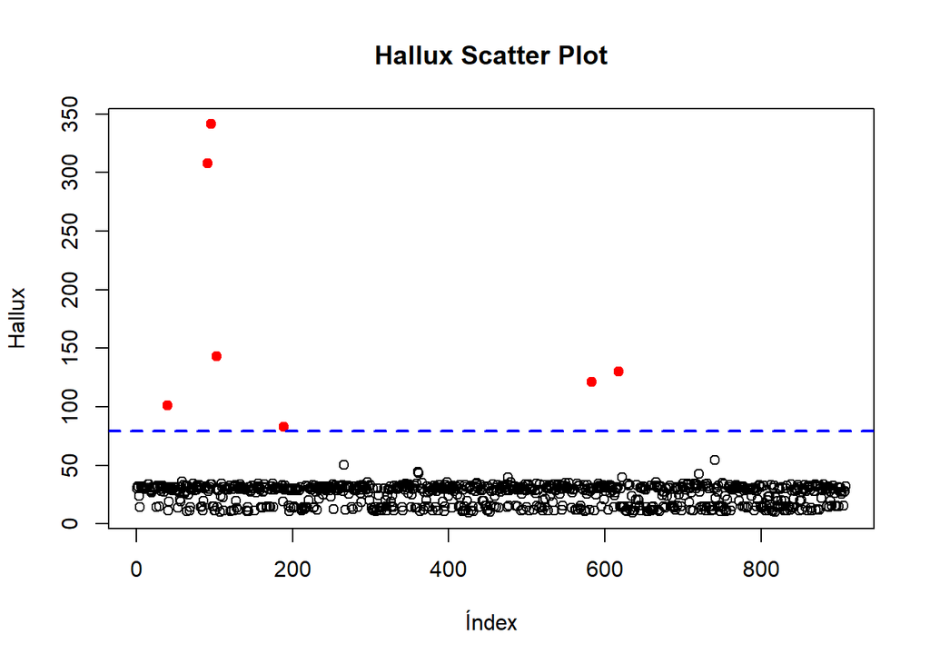

```r
plot(hawks_limpio2$Hallux,
     main = "Hallux Scatter Plot",
     ylab = "Hallux",
     xlab = "Índex",
     pch = ifelse(hawks_limpio2$Hallux < lower_bound_hallux | hawks_limpio2$Hallux > upper_bound_hallux, 19, 1),
     col = ifelse(hawks_limpio2$Hallux < lower_bound_hallux | hawks_limpio2$Hallux > upper_bound_hallux, "red", "black"))

abline(h = c(lower_bound_hallux, upper_bound_hallux), col = "blue", lwd = 2, lty = 2)
```

Finally, to **confirm our hypothesis**, we perform the **outlier analysis on the entire cleaned dataset**.

We verify that **only those 7 Hallux values** are identified as **outliers**.

```
## Outliers in the column: Month
##  [1] Month       Day         Year        CaptureTime ReleaseTime BandNumber
##  [7] Species     Age         Sex         Wing        Weight      Culmen
## [13] Hallux      Tail
## <0 rows> (o 0- extensión row.names)
## Number of detected outliers: 0
```

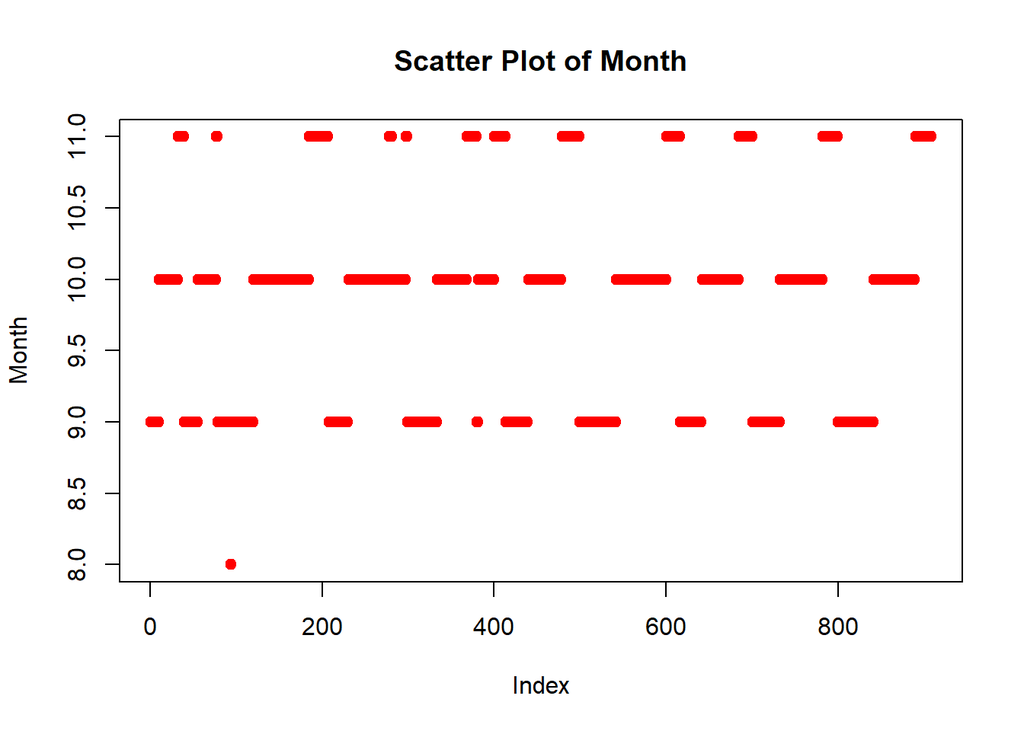

```
## Outliers in the column: Day
##  [1] Month       Day         Year        CaptureTime ReleaseTime BandNumber
##  [7] Species     Age         Sex         Wing        Weight      Culmen
## [13] Hallux      Tail
## <0 rows> (o 0- extensión row.names)
## Number of detected outliers: 0
```

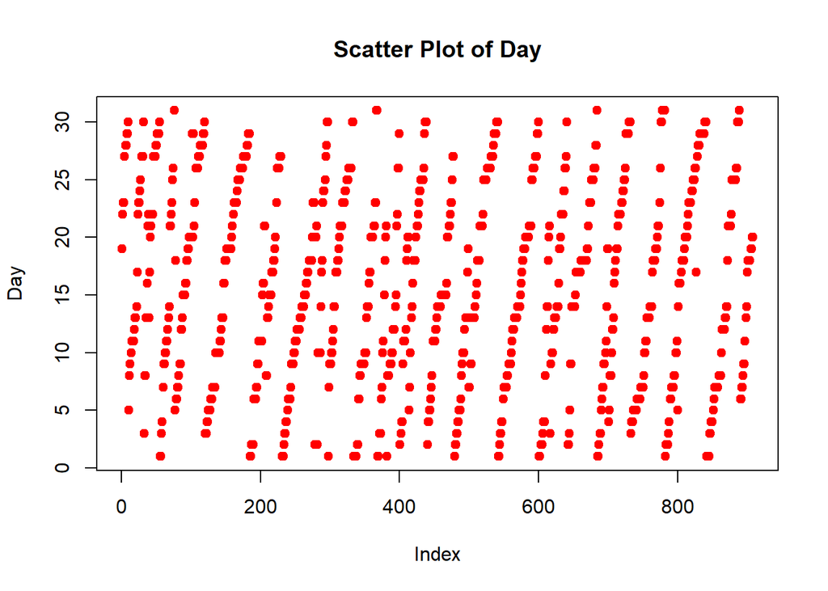

```
## Outliers in the column: Year
##  [1] Month       Day         Year        CaptureTime ReleaseTime BandNumber
##  [7] Species     Age         Sex         Wing        Weight      Culmen
## [13] Hallux      Tail
## <0 rows> (o 0- extensión row.names)
## Number of detected outliers: 0
```

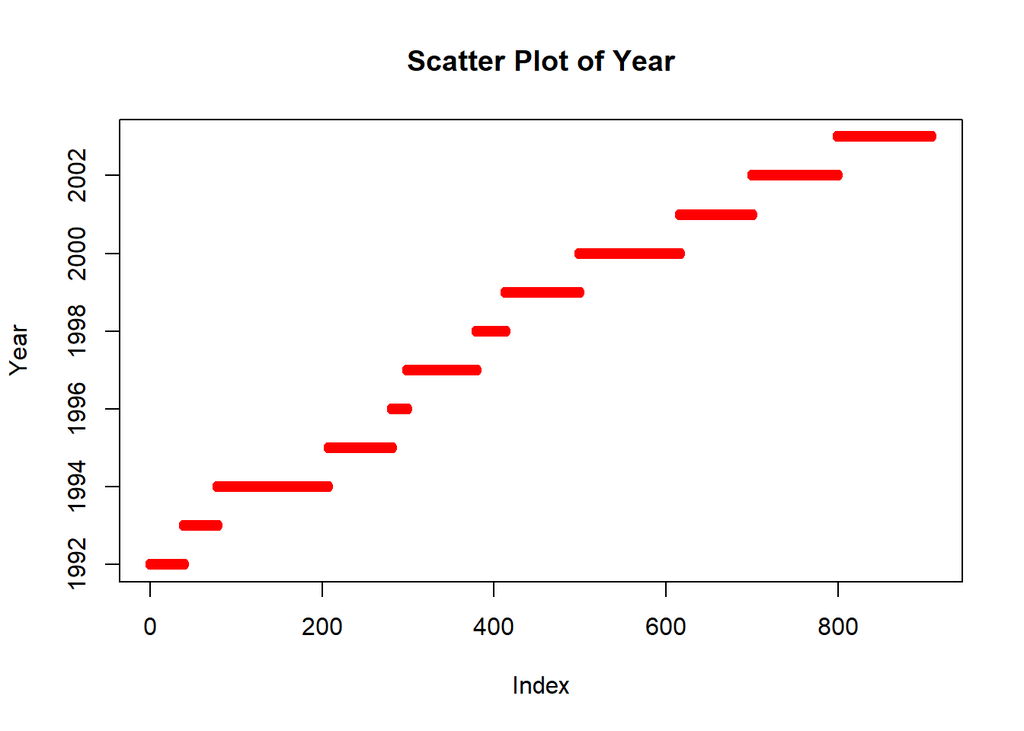

```
## Outliers in the column: Wing
##  [1] Month       Day         Year        CaptureTime ReleaseTime BandNumber
##  [7] Species     Age         Sex         Wing        Weight      Culmen
## [13] Hallux      Tail
## <0 rows> (o 0- extensión row.names)
## Number of detected outliers: 0
```

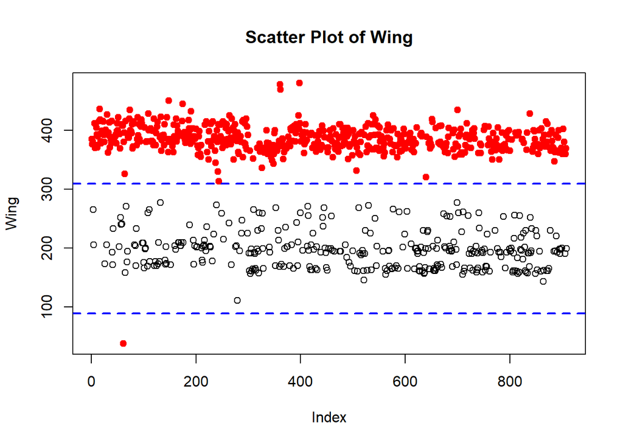

```
## Outliers in the column: Weight
##  [1] Month       Day         Year        CaptureTime ReleaseTime BandNumber
##  [7] Species     Age         Sex         Wing        Weight      Culmen
## [13] Hallux      Tail
## <0 rows> (o 0- extensión row.names)
## Number of detected outliers: 0
```

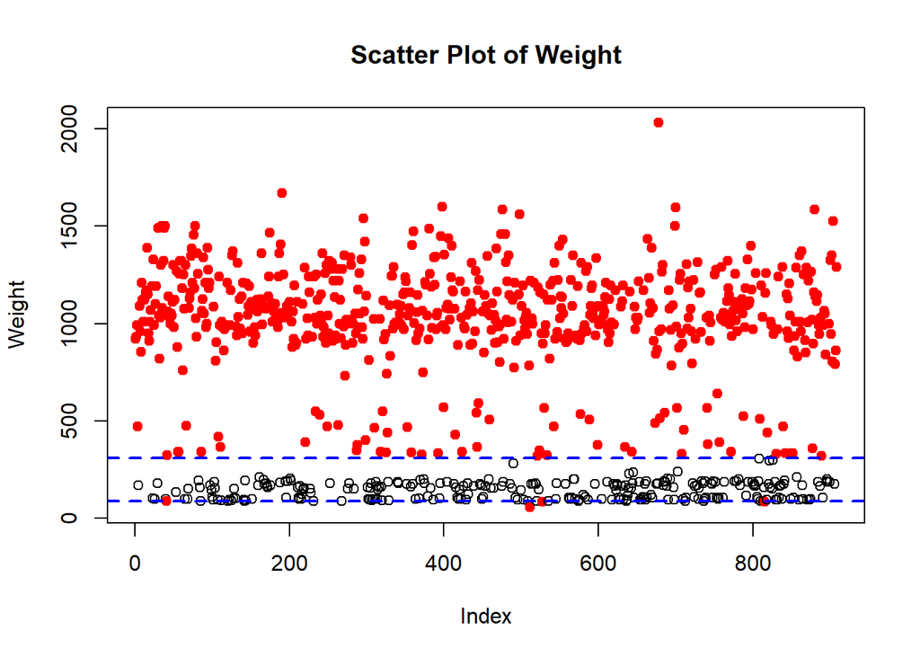

```
## Outliers in the column: Culmen
##  [1] Month       Day         Year        CaptureTime ReleaseTime BandNumber
##  [7] Species     Age         Sex         Wing        Weight      Culmen
## [13] Hallux      Tail
## <0 rows> (o 0- extensión row.names)
## Number of detected outliers: 0
```

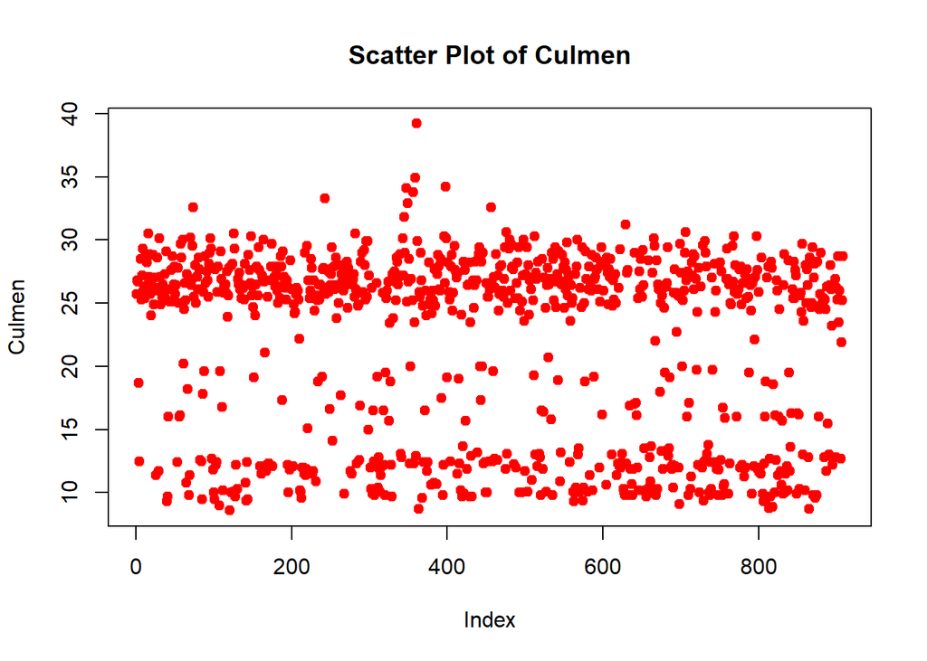

```
## Outliers in the column: Hallux
##   Month Day Year CaptureTime ReleaseTime BandNumber Species Age Sex Wing Weight
## 1     9  13 1993       14:25              173-19904      SS   I   M  193    100
## 2     9  15 1994       13:35             1387-79108      RT   I      410   1210
## 3     9  19 1994       12:58             1207-64604      RT   I      418   1180
## 4     9  20 1994       14:00             2003-58437      SS   A   F  198    188
## 5    11   2 1994       12:20             1207-64619      RT   I      401   1405
## 6    10  20 2000       12:38             1142-09241      SS   A   M  170    110
## 7     9   9 2001       11:51             1142-19244      SS   I   M  164     95
##   Culmen Hallux Tail
## 1    9.3  101.0  144
## 2   27.5  308.0  227
## 3   30.1  341.4  235
## 4   12.2  143.0  150
## 5   29.1   82.8  235
## 6   11.4  121.0  135
## 7   11.4  130.0  136
## Number of detected outliers: 7
```

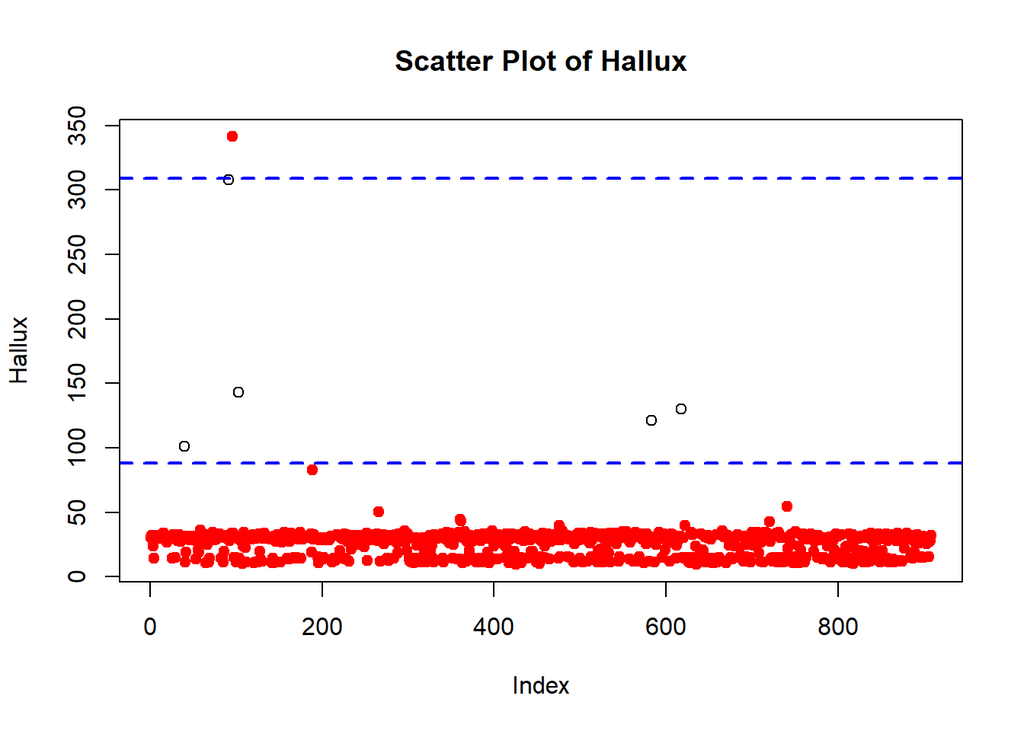

```
## Outliers in the column: Tail
##  [1] Month       Day         Year        CaptureTime ReleaseTime BandNumber
##  [7] Species     Age         Sex         Wing        Weight      Culmen
## [13] Hallux      Tail
## <0 rows> (o 0- extensión row.names)
## Number of detected outliers: 0
```

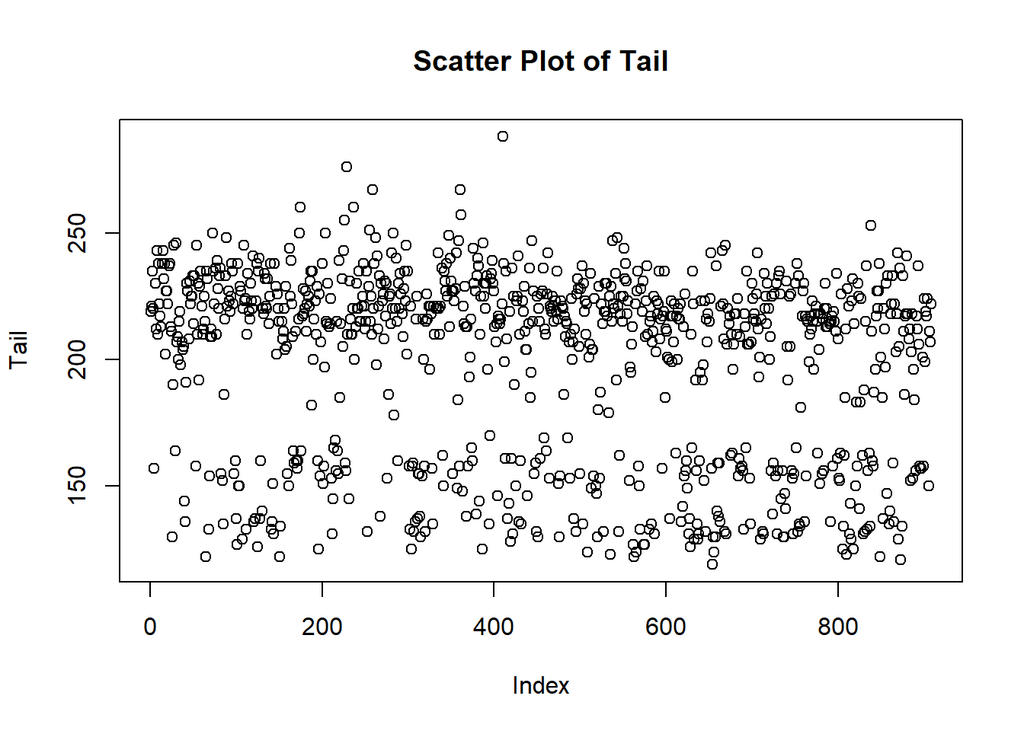

```r
detect_outliers_sd <- function(data, column) {
  mean_value <- mean(data[[column]], na.rm = TRUE)
  sd_value <- sd(data[[column]], na.rm = TRUE)

  lower_bound <- mean_value - 3 * sd_value
  upper_bound <- mean_value + 3 * sd_value

  outliers <- data %>% filter(data[[column]] < lower_bound | data[[column]] > upper_bound)

  outlier_count <- nrow(outliers)

  return(list(outliers = outliers, lower_bound = lower_bound, upper_bound = upper_bound, count = outlier_count))
}

numeric_columns <- sapply(hawks_limpio2, is.numeric)
outlier_results <- list()

for (column_name in names(hawks_limpio2)[numeric_columns]) {
  result <- detect_outliers_sd(hawks_limpio2, column_name)
  outlier_results[[column_name]] <- result
}

for (column_name in names(outlier_results)) {
  cat(paste("Outliers in the column:", column_name, "\n"))
  print(outlier_results[[column_name]]$outliers)
  cat(paste("Number of detected outliers:", outlier_results[[column_name]]$count, "\n\n"))

  plot(hawks_limpio2[[column_name]],
       main = paste("Scatter Plot of", column_name),
       ylab = column_name,
       xlab = "Index",
       pch = ifelse(hawks_limpio2[[column_name]] < result$lower_bound | hawks_limpio2[[column_name]] > result$upper_bound, 19, 1),
       col = ifelse(hawks_limpio2[[column_name]] < result$lower_bound | hawks_limpio2[[column_name]] > result$upper_bound, "red", "black"))

  abline(h = c(result$lower_bound, result$upper_bound), col = "blue", lwd = 2, lty = 2)
}
```

Outlier attributes are identified in the same way as we did for **missing values detection**, but now focusing on **outliers**.

```r
all_outliers <- data.frame()

for (column_name in names(hawks_limpio2)[numeric_columns]) {
  result <- outlier_results[[column_name]]

  if (result$count > 0) {
    cat(paste("Outliers in the column:", column_name, "\n"))
    print(result$outliers)


    all_outliers <- bind_rows(all_outliers, result$outliers)
  }
}
```

```
## Outliers in the column: Hallux
##   Month Day Year CaptureTime ReleaseTime BandNumber Species Age Sex Wing Weight
## 1     9  13 1993       14:25              173-19904      SS   I   M  193    100
## 2     9  15 1994       13:35             1387-79108      RT   I      410   1210
## 3     9  19 1994       12:58             1207-64604      RT   I      418   1180
## 4     9  20 1994       14:00             2003-58437      SS   A   F  198    188
## 5    11   2 1994       12:20             1207-64619      RT   I      401   1405
## 6    10  20 2000       12:38             1142-09241      SS   A   M  170    110
## 7     9   9 2001       11:51             1142-19244      SS   I   M  164     95
##   Culmen Hallux Tail
## 1    9.3  101.0  144
## 2   27.5  308.0  227
## 3   30.1  341.4  235
## 4   12.2  143.0  150
## 5   29.1   82.8  235
## 6   11.4  121.0  135
## 7   11.4  130.0  136
```

```r
cat("Complete rows of detected outliers:\n")
```

```
## Complete rows of detected outliers:
```

```r
print(all_outliers)
```

```
##   Month Day Year CaptureTime ReleaseTime BandNumber Species Age Sex Wing Weight
## 1     9  13 1993       14:25              173-19904      SS   I   M  193    100
## 2     9  15 1994       13:35             1387-79108      RT   I      410   1210
## 3     9  19 1994       12:58             1207-64604      RT   I      418   1180
## 4     9  20 1994       14:00             2003-58437      SS   A   F  198    188
## 5    11   2 1994       12:20             1207-64619      RT   I      401   1405
## 6    10  20 2000       12:38             1142-09241      SS   A   M  170    110
## 7     9   9 2001       11:51             1142-19244      SS   I   M  164     95
##   Culmen Hallux Tail
## 1    9.3  101.0  144
## 2   27.5  308.0  227
## 3   30.1  341.4  235
## 4   12.2  143.0  150
## 5   29.1   82.8  235
## 6   11.4  121.0  135
## 7   11.4  130.0  136
```

An attempt was made to **remove the outlier rows**, but it was **unsuccessful**

To address this, an **internet search was conducted**, leading to a study that performs **outlier imputation** ->  
[*https://rpubs.com/Kamaranis/unsupervised_methods*](https://rpubs.com/Kamaranis/unsupervised_methods).

We applied the method from this study to our dataset, and it **worked correctly**.

```r
media_hallux_especie_edad <- hawks_limpio2 %>%
  group_by(Species, Age) %>%
  summarise(media_hallux = mean(Hallux, na.rm = TRUE), .groups = 'drop')

all_outliers <- data.frame()

for (column_name in names(hawks_limpio2)[numeric_columns]) {
  result <- outlier_results[[column_name]]

  if (result$count > 0) {
    cat(paste("Outliers in the column:", column_name, "\n"))
    print(result$outliers)

    all_outliers <- bind_rows(all_outliers, result$outliers)
  }
}
```

```
## Outliers in the column: Hallux
##   Month Day Year CaptureTime ReleaseTime BandNumber Species Age Sex Wing Weight
## 1     9  13 1993       14:25              173-19904      SS   I   M  193    100
## 2     9  15 1994       13:35             1387-79108      RT   I      410   1210
## 3     9  19 1994       12:58             1207-64604      RT   I      418   1180
## 4     9  20 1994       14:00             2003-58437      SS   A   F  198    188
## 5    11   2 1994       12:20             1207-64619      RT   I      401   1405
## 6    10  20 2000       12:38             1142-09241      SS   A   M  170    110
## 7     9   9 2001       11:51             1142-19244      SS   I   M  164     95
##   Culmen Hallux Tail
## 1    9.3  101.0  144
## 2   27.5  308.0  227
## 3   30.1  341.4  235
## 4   12.2  143.0  150
## 5   29.1   82.8  235
## 6   11.4  121.0  135
## 7   11.4  130.0  136
```

```r
cat("Complete rows of detected outliers:\n")
```

```
## Complete rows of detected outliers:
```

```r
print(all_outliers)
```

```
##   Month Day Year CaptureTime ReleaseTime BandNumber Species Age Sex Wing Weight
## 1     9  13 1993       14:25              173-19904      SS   I   M  193    100
## 2     9  15 1994       13:35             1387-79108      RT   I      410   1210
## 3     9  19 1994       12:58             1207-64604      RT   I      418   1180
## 4     9  20 1994       14:00             2003-58437      SS   A   F  198    188
## 5    11   2 1994       12:20             1207-64619      RT   I      401   1405
## 6    10  20 2000       12:38             1142-09241      SS   A   M  170    110
## 7     9   9 2001       11:51             1142-19244      SS   I   M  164     95
##   Culmen Hallux Tail
## 1    9.3  101.0  144
## 2   27.5  308.0  227
## 3   30.1  341.4  235
## 4   12.2  143.0  150
## 5   29.1   82.8  235
## 6   11.4  121.0  135
## 7   11.4  130.0  136
```

```r
hallux_upper_limit <- 55.9

for (i in 1:nrow(hawks_limpio2)) {

  if (hawks_limpio2$Hallux[i] > hallux_upper_limit) {
    mean_hallux <- media_hallux_especie_edad$media_hallux[
      media_hallux_especie_edad$Species == hawks_limpio2$Species[i] &
      media_hallux_especie_edad$Age == hawks_limpio2$Age[i]
    ]
    hawks_limpio2$Hallux[i] <- mean_hallux
  }
}

remaining_outliers_hallux <- detect_outliers_sd(hawks_limpio2, "Hallux")
cat("Remaining outliers in Hallux after imputation:\n")
```

```
## Remaining outliers in Hallux after imputation:
```

```r
print(remaining_outliers_hallux$outliers)
```

```
##   Month Day Year CaptureTime ReleaseTime BandNumber Species Age Sex Wing Weight
## 1    10  16 1995       12:35             1387-79172      RT   I      387   1120
## 2    10   5 2002       14:27             1705-37416      CH   A   F  260    565
##   Culmen Hallux Tail
## 1   26.8   50.2  221
## 2   19.7   54.5  205
```

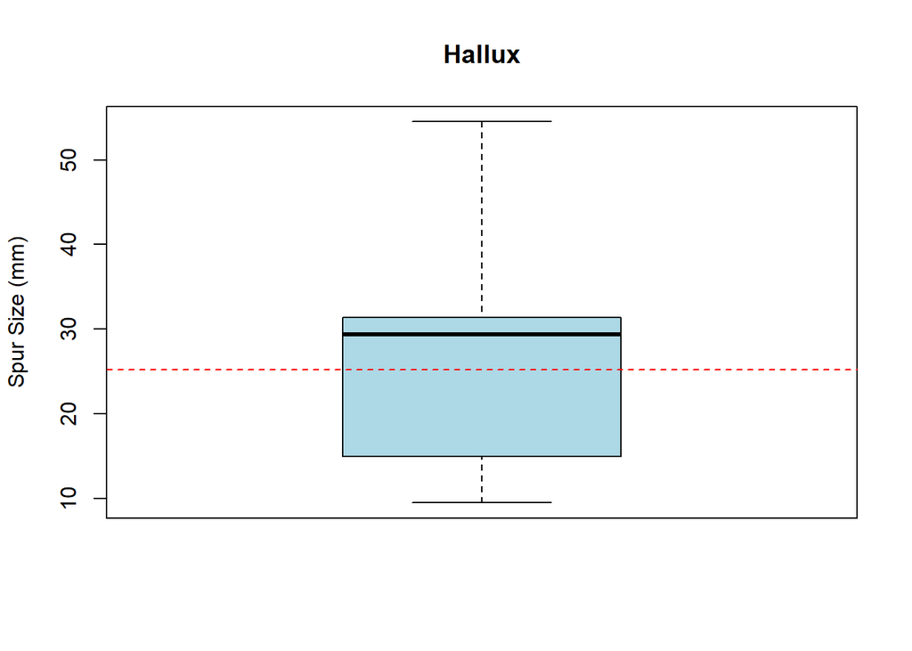

```r
boxplot(hawks_limpio2$Hallux,
        main = "Hallux",
        ylab = "Spur Size (mm)",
        outline = TRUE,
        col = "lightblue")

abline(h = mean(hawks_limpio2$Hallux, na.rm = TRUE), col = "red", lty = 2)
```

```r
summary(hawks_limpio2)
```

```
##      Month             Day             Year       CaptureTime   ReleaseTime
##  Min.   : 8.000   Min.   : 1.00   Min.   :1992   11:35  : 14          :842
##  1st Qu.: 9.000   1st Qu.: 9.00   1st Qu.:1995   13:30  : 14   11:00  :  2
##  Median :10.000   Median :16.00   Median :1999   11:45  : 13   11:35  :  2
##  Mean   : 9.843   Mean   :15.74   Mean   :1998   12:10  : 13   12:05  :  2
##  3rd Qu.:10.000   3rd Qu.:23.00   3rd Qu.:2001   14:00  : 13   12:50  :  2
##  Max.   :11.000   Max.   :31.00   Max.   :2003   13:05  : 12   13:32  :  2
##                                                  (Other):829   (Other): 56
##       BandNumber  Species  Age     Sex          Wing           Weight
##            :  2   CH: 70   A:224    :576   Min.   : 37.2   Min.   :  56.0
##  1142-09240:  1   RT:577   I:684   F:174   1st Qu.:202.0   1st Qu.: 185.0
##  1142-09241:  1   SS:261           M:158   Median :370.0   Median : 970.0
##  1142-09242:  1                            Mean   :315.6   Mean   : 770.5
##  1142-18229:  1                            3rd Qu.:390.0   3rd Qu.:1120.0
##  1142-19209:  1                            Max.   :480.0   Max.   :2030.0
##  (Other)   :901
##      Culmen          Hallux           Tail
##  Min.   : 8.60   Min.   : 9.50   Min.   :119.0
##  1st Qu.:12.78   1st Qu.:15.00   1st Qu.:160.0
##  Median :25.50   Median :29.40   Median :214.0
##  Mean   :21.79   Mean   :25.21   Mean   :198.8
##  3rd Qu.:27.30   3rd Qu.:31.40   3rd Qu.:225.0
##  Max.   :39.20   Max.   :54.50   Max.   :288.0
##
```

## Exploratory Data Analysis

After **cleaning the dataset**, we will **analyze** it using **various visualizations** to gain a **general overview** and start drawing **preliminary conclusions**.

For example, the **most common species** in our dataset is **“RT”** (Red-tailed Hawk).

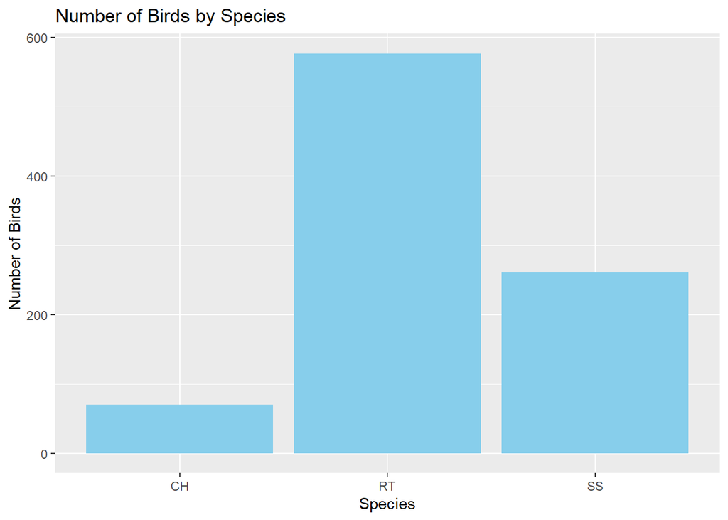

```r
ggplot(hawks_limpio2, aes(x = Species)) +
  geom_bar(fill = "skyblue") +
  labs(title = "Number of Birds by Species", x = "Species", y = "Number of Birds")
```

Species: Bird species classification:  
- **“CH”** = Cooper’s Hawk  
- **“RT”** = Red-tailed Hawk  
- **“SS”** = Sharp-shinned Hawk

```r
especies_count <- hawks_limpio2 %>%
  group_by(Species) %>%
  summarize(Count = n()) %>%
  arrange(desc(Count))

print(especies_count)
```

```
## # A tibble: 3 × 2
##   Species Count
##   <fct>   <int>
## 1 RT        577
## 2 SS        261
## 3 CH         70
```

We create a **relationship between wing length and weight**.

This **graph is crucial**, as we can already identify **three distinct groups**, providing an **important clue** that we may have **three clusters**.

However, we continue with the **exploratory analysis**.

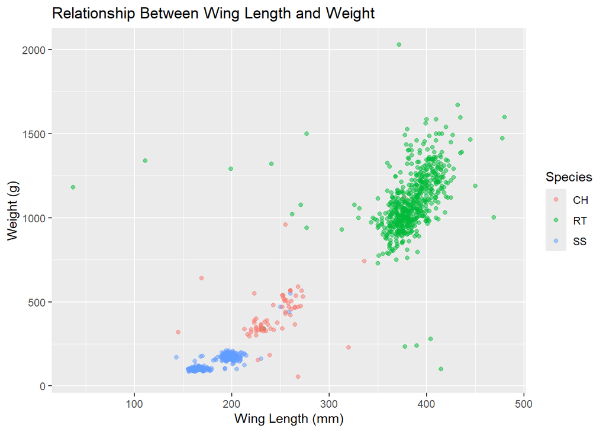

```r
ggplot(hawks_limpio2, aes(x = Wing, y = Weight, color = Species)) +
  geom_point(alpha = 0.5) +
  labs(title = "Relationship Between Wing Length and Weight",
       x = "Wing Length (mm)",
       y = "Weight (g)")
```

We analyze the **number of birds captured per year** and notice an **anomaly in 1996**.

After a brief investigation, we found that **1996 was one of the harshest winters on record**, which could be a **significant factor for the analysis**.

**Reference for the indicated data:**  
[*https://www.thegazette.com/curious-iowa/curious-iowa-when-did-iowa-have-record-setting-weather/*](https://www.thegazette.com/curious-iowa/curious-iowa-when-did-iowa-have-record-setting-weather/)

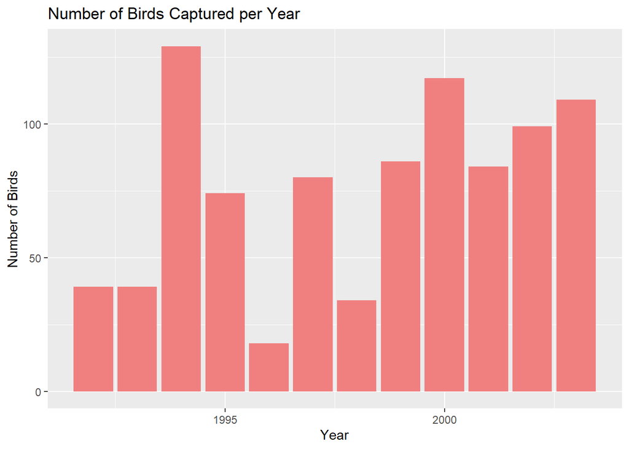

```r
ggplot(hawks_limpio2, aes(x = Year)) +
  geom_bar(fill = "lightcoral") +
  labs(title = "Number of Birds Captured per Year",
       x = "Year",
       y = "Number of Birds")
```

We extract another **key insight**: **most of the birds in our dataset are not of advanced age**.

Can we conclude that **mortality is very high at a certain age?**

We **lack additional data**, such as the **exact classification of age groups**, but this remains a **crucial point for deeper analysis**.

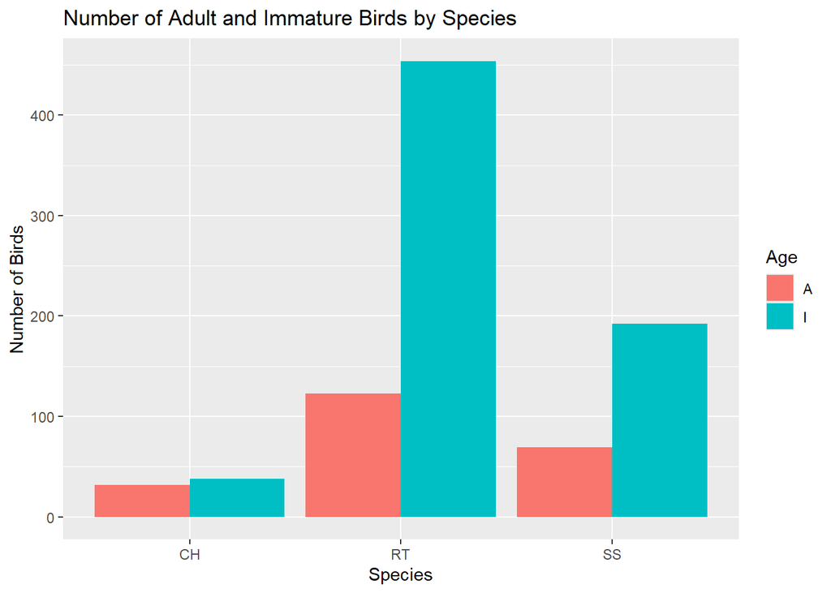

```r
ggplot(hawks_limpio2, aes(x = Species, fill = Age)) +
  geom_bar(position = "dodge") +
  labs(title = "Number of Adult and Immature Birds by Species",
       x = "Species",
       y = "Number of Birds")
```

We have **another key insight** supporting the idea that **three clusters** could be a great option.

The **weight distribution** clearly shows **three distinct groups**.

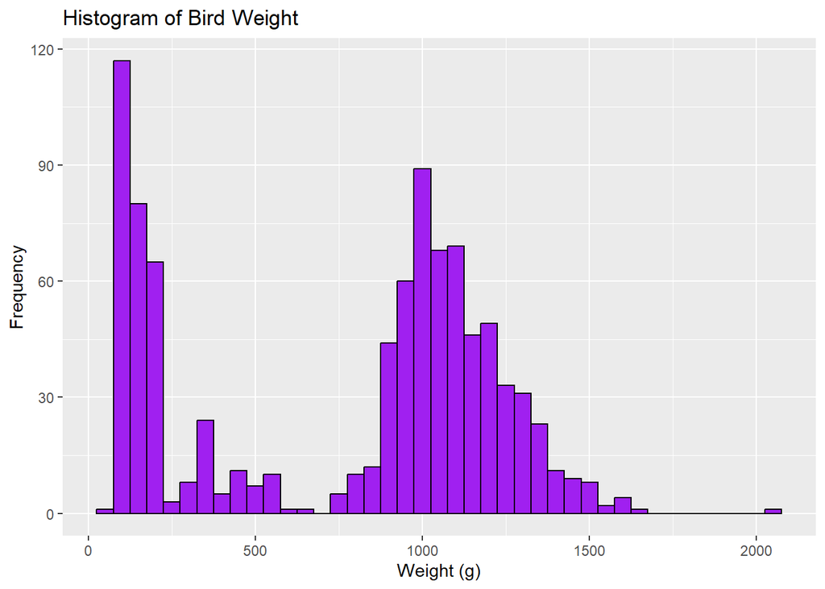

```r
ggplot(hawks_limpio2, aes(x = Weight)) +
  geom_histogram(binwidth = 50, fill = "purple", color = "black") +
  labs(title = "Histogram of Bird Weight",
       x = "Weight (g)",
       y = "Frequency")
```

## K-Means Clustering

We begin our **K-Means study** by selecting **numerical variables**, as **K-Means can only handle numerical data**.

We also include **Sex** and **Age**, even though they are **categorical variables**.

```r
hawks_data <- hawks_limpio2 %>%
  select(Wing, Weight, Culmen, Hallux, Sex, Age)

hawks_data
```

```
##         Wing    Weight   Culmen   Hallux Sex Age
## 1   385.0000  920.0000 25.70000 30.10000       I
## 2   376.0000  930.0000 26.81197 32.23097       I
## 3   381.0000  990.0000 26.70000 31.30000       I
## 4   265.0000  470.0000 18.70000 23.50000   F   I
## 5   205.0000  170.0000 12.50000 14.30000   F   I
## 6   412.0000 1090.0000 28.50000 32.20000       I
## 7   370.0000  960.0000 25.30000 30.10000       I
## 8   375.0000  855.0000 27.20000 30.00000       A
## 9   412.0000 1210.0000 29.30000 31.30000       A
## 10  405.0000 1120.0000 26.00000 30.20000       I
## 11  393.0000 1010.0000 26.30000 30.80000       I
## 12  371.0000 1010.0000 25.40000 29.70000       I
## 13  390.0000 1120.0000 28.90000 30.90000       A
## 14  393.0000 1161.4132 28.20000 30.60000       A
```

[output cut: 894 more lines]

In our **analysis**, we selected **two categorical variables** to **convert into numerical format** using the **dummy encoding method**.

We assign **binary values (0 and 1)** to the **Age** categories (**Adult = 1, Immature = 0**) and **Sex** categories (**Male = 1, Female = 0**).

```r
hawks_limpio2 <- hawks_limpio2 %>%
  mutate(
    Sex_M = ifelse(Sex == "M", 1, 0),
    Sex_F = ifelse(Sex == "F", 1, 0),


    Age_A = ifelse(Age == "A", 1, 0),
    Age_I = ifelse(Age == "I", 1, 0)
  )

print(hawks_limpio2)
```

```
##     Month Day Year CaptureTime ReleaseTime  BandNumber Species Age Sex     Wing
## 1       9  19 1992       13:30               877-76317      RT   I     385.0000
## 2       9  22 1992       10:30               877-76318      RT   I     376.0000
## 3       9  23 1992       12:45               877-76319      RT   I     381.0000
## 4       9  23 1992       10:50               745-49508      CH   I   F 265.0000
## 5       9  27 1992       11:15              1253-98801      SS   I   F 205.0000
## 6       9  28 1992       11:25             1207-55910       RT   I     412.0000
## 7       9  28 1992       13:30               877-76320      RT   I     370.0000
## 8       9  29 1992       11:45               877-76321      RT   A     375.0000
## 9       9  29 1992       15:35               877-76322      RT   A     412.0000
## 10      9  30 1992       13:45              1207-55911      RT   I     405.0000
## 11     10   5 1992       13:30               877-76323      RT   I     393.0000
## 12     10   8 1992       13:45               877-76324      RT   I     371.0000
## 13     10   9 1992       12:30               877-76325      RT   A     390.0000
## 14     10  10 1992       11:05              1207-55917      RT   A     393.0000
```

[output cut: 1803 more lines]

Now, we create a **subset of the dataset** containing **only numerical variables**, including **categorical variables converted into numerical format using dummy encoding**.

```r
hawks_selected <- hawks_limpio2 %>%
  select(Wing, Weight, Culmen, Hallux, Sex_M, Sex_F, Age_A, Age_I)

print(hawks_selected)
```

```
##         Wing    Weight   Culmen   Hallux Sex_M Sex_F Age_A Age_I
## 1   385.0000  920.0000 25.70000 30.10000     0     0     0     1
## 2   376.0000  930.0000 26.81197 32.23097     0     0     0     1
## 3   381.0000  990.0000 26.70000 31.30000     0     0     0     1
## 4   265.0000  470.0000 18.70000 23.50000     0     1     0     1
## 5   205.0000  170.0000 12.50000 14.30000     0     1     0     1
## 6   412.0000 1090.0000 28.50000 32.20000     0     0     0     1
## 7   370.0000  960.0000 25.30000 30.10000     0     0     0     1
## 8   375.0000  855.0000 27.20000 30.00000     0     0     1     0
## 9   412.0000 1210.0000 29.30000 31.30000     0     0     1     0
## 10  405.0000 1120.0000 26.00000 30.20000     0     0     0     1
## 11  393.0000 1010.0000 26.30000 30.80000     0     0     0     1
## 12  371.0000 1010.0000 25.40000 29.70000     0     0     0     1
## 13  390.0000 1120.0000 28.90000 30.90000     0     0     1     0
## 14  393.0000 1161.4132 28.20000 30.60000     0     0     1     0
```

[output cut: 894 more lines]

As we can observe, the transformation was **successfully applied**.

Now, we just need to **normalize** this dataset.

We must consider that **dummy numerical variables should not be scaled**, so we **exclude them from the scaling process**.

**Reference:**  
[*https://stackoverflow.com/questions/74365630/how-to-avoid-scaling-dummy-variables-in-dataframe-in-r*](https://stackoverflow.com/questions/74365630/how-to-avoid-scaling-dummy-variables-in-dataframe-in-r)

```r
hawks_scaled <- hawks_selected %>%
  mutate(
    Wing = scale(Wing),
    Weight = scale(Weight),
    Culmen = scale(Culmen),
    Hallux = scale(Hallux)  )
print(hawks_scaled)
```

```
##            Wing       Weight      Culmen      Hallux Sex_M Sex_F Age_A Age_I
## 1    0.72901533  0.323037860  0.53643756  0.58802795     0     0     0     1
## 2    0.63453308  0.344646534  0.68899769  0.84440031     0     0     0     1
## 3    0.68702322  0.474298581  0.67363520  0.73239710     0     0     0     1
## 4   -0.53074792 -0.649352494 -0.42394592 -0.20600240     0     1     0     1
## 5   -1.16062955 -1.297612730 -1.27457130 -1.31283258     0     1     0     1
## 6    1.01246206  0.690385326  0.92059096  0.84067397     0     0     0     1
## 7    0.57154492  0.409472558  0.48155851  0.58802795     0     0     0     1
## 8    0.62403506  0.182581475  0.74223402  0.57599719     0     0     1     0
## 9    1.01246206  0.949689421  1.03034907  0.73239710     0     0     1     0
## 10   0.93897587  0.755211350  0.57759685  0.60005871     0     0     0     1
## 11   0.81299955  0.517515930  0.61875615  0.67224329     0     0     0     1
## 12   0.58204295  0.517515930  0.49527827  0.53990490     0     0     0     1
## 13   0.78150546  0.755211350  0.97547001  0.68427405     0     0     1     0
## 14   0.81299955  0.844699836  0.87943166  0.64818176     0     0     1     0
```

[output cut: 894 more lines]

We have prepared our dataset for the **K-Means clustering study** by following a series of steps:

1. **Dataset Cleaning**:
   - Missing values were either **removed** or **imputed with the mean**, considering that the number of missing attributes was **low**.
2. **Variable Normalization**:
   - All numerical variables were **normalized** to ensure they contribute **equally** to the analysis.
3. **Creation of Dummy Variables**:
   - Dummy variables were generated for **categorical features**, specifically for **two categorical attributes**.

With the **cleaned and prepared dataset**, we now proceed with the **K-Means analysis**.

To do this, we will conduct **three tests** using **2, 3, and 5 clusters**.

This approach will allow us to evaluate how the data clusters under different scenarios and help determine the **optimal number of clusters** for our analysis.

```r
set.seed(123)
dos_grupos <- 2
kmeans2_result <- kmeans(hawks_scaled, centers = dos_grupos)
tres_grupos <- 3
kmeans3_result <- kmeans(hawks_scaled, centers = tres_grupos)
cinco_grupos <- 5
kmeans5_result <- kmeans(hawks_scaled, centers = cinco_grupos)

hawks_limpio2$Cluster2 <- as.factor(kmeans2_result$cluster)
hawks_limpio2$Cluster3 <- as.factor(kmeans3_result$cluster)
hawks_limpio2$Cluster5 <- as.factor(kmeans5_result$cluster)
```

Now, we will **visualize the clusters** and draw **conclusions** based on the results.

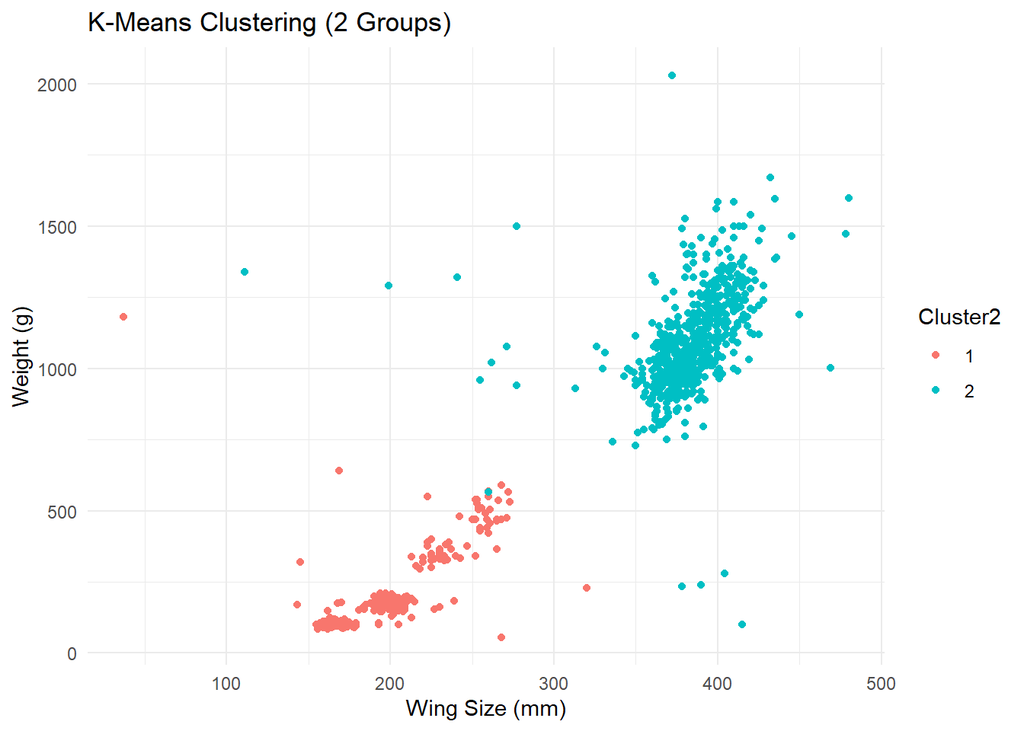

```r
ggplot(hawks_limpio2, aes(x = Wing, y = Weight, color = Cluster2)) +
  geom_point() +
  labs(title = "K-Means Clustering (2 Groups)",
       x = "Wing Size (mm)",
       y = "Weight (g)") +
  theme_minimal()
```

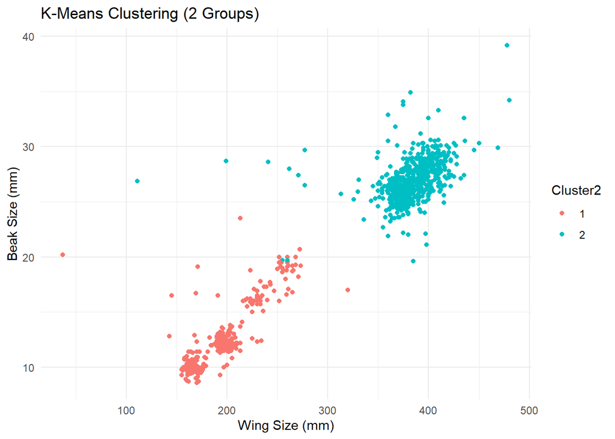

```r
ggplot(hawks_limpio2, aes(x = Wing, y = Culmen, color = Cluster2)) +
  geom_point() +
  labs(title = "K-Means Clustering (2 Groups)",
       x = "Wing Size (mm)",
       y = "Beak Size (mm)") +
  theme_minimal()
```

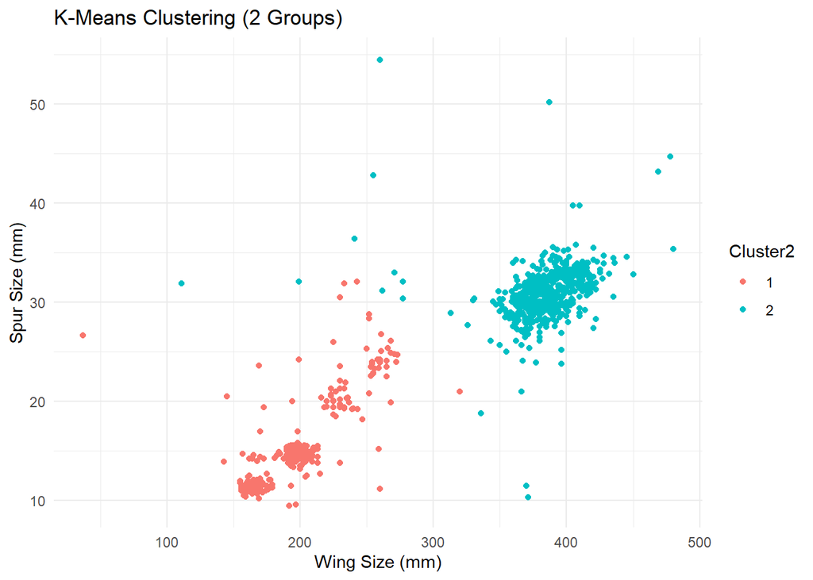

```r
ggplot(hawks_limpio2, aes(x = Wing, y = Hallux, color = Cluster2)) +
  geom_point() +
  labs(title = "K-Means Clustering (2 Groups)",
       x = "Wing Size (mm)",
       y = "Spur Size (mm)") +
  theme_minimal()
```

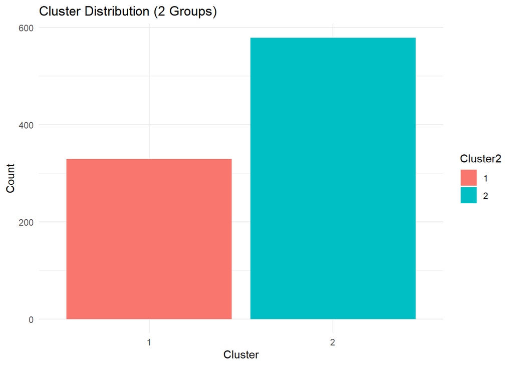

```r
ggplot(hawks_limpio2, aes(x = Cluster2, fill = Cluster2)) +
  geom_bar() +
  labs(title = "Cluster Distribution (2 Groups)",
       x = "Cluster",
       y = "Count") +
  theme_minimal()
```

Our **2-cluster option** seems like a **good choice**, as the distribution appears **well-defined**, clearly showing **two groups**.

However, we will continue our analysis with **3 clusters** to further evaluate the data.

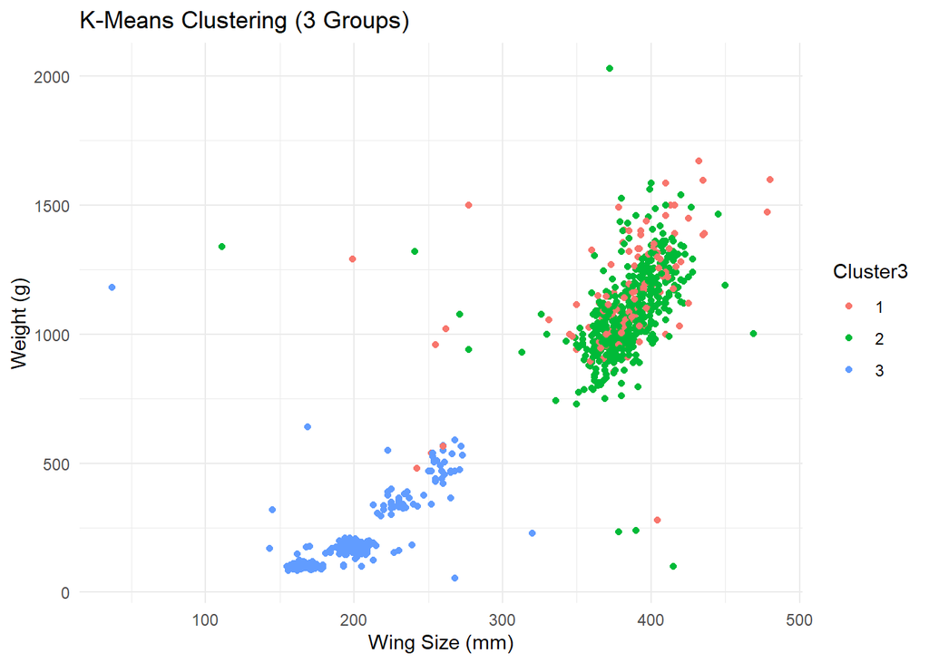

```r
ggplot(hawks_limpio2, aes(x = Wing, y = Weight, color = Cluster3)) +
  geom_point() +
  labs(title = "K-Means Clustering (3 Groups)",
       x = "Wing Size (mm)",
       y = "Weight (g)") +
  theme_minimal()
```

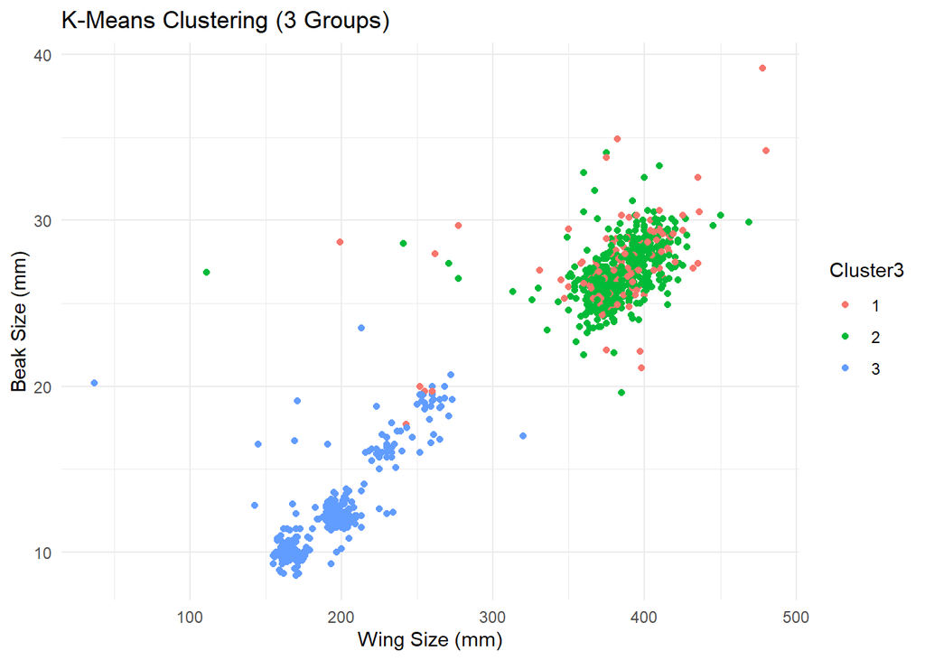

```r
ggplot(hawks_limpio2, aes(x = Wing, y = Culmen, color = Cluster3)) +
  geom_point() +
  labs(title = "K-Means Clustering (3 Groups)",
       x = "Wing Size (mm)",
       y = "Beak Size (mm)") +
  theme_minimal()
```

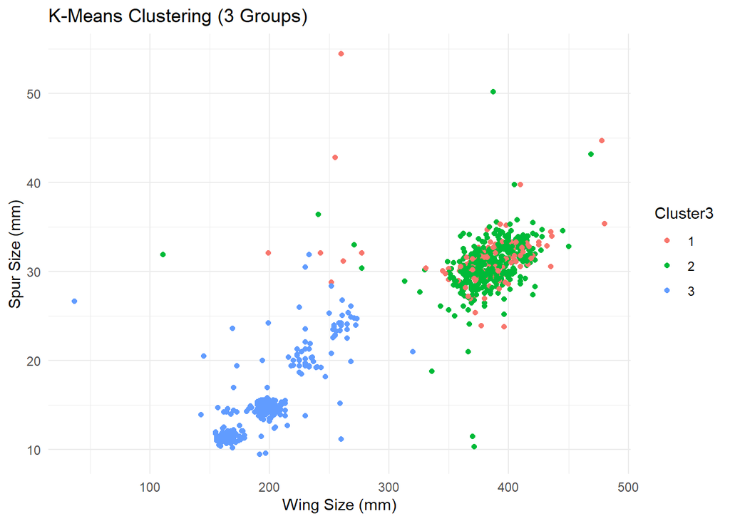

```r
ggplot(hawks_limpio2, aes(x = Wing, y = Hallux, color = Cluster3)) +
  geom_point() +
  labs(title = "K-Means Clustering (3 Groups)",
       x = "Wing Size (mm)",
       y = "Spur Size (mm)") +
  theme_minimal()
```

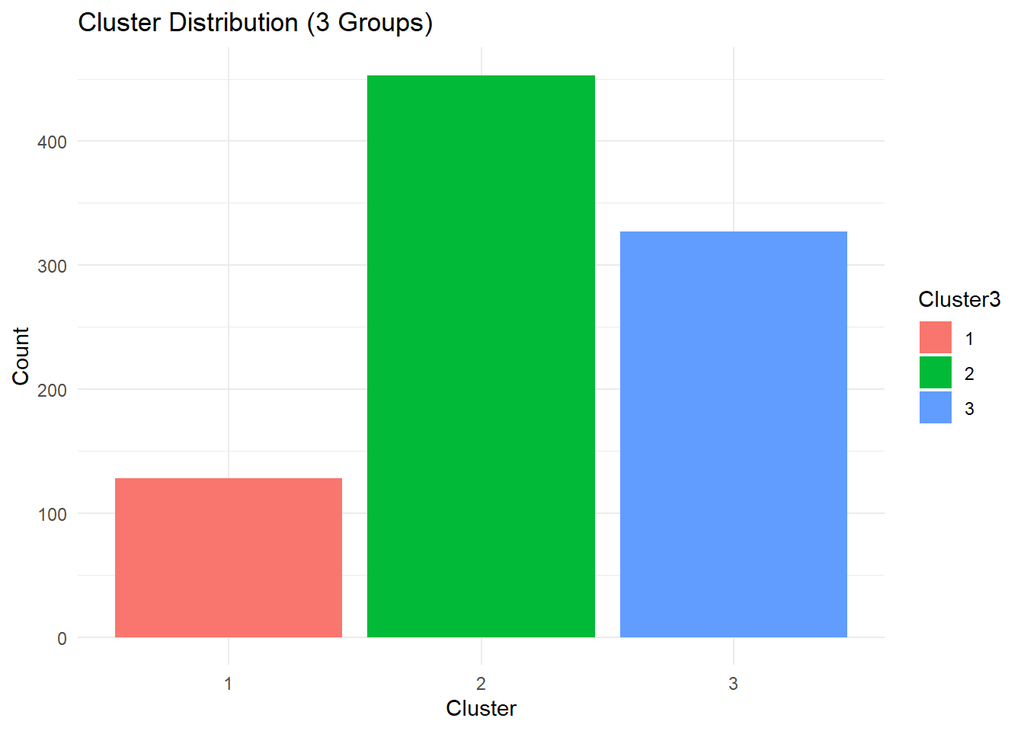

```r
ggplot(hawks_limpio2, aes(x = Cluster3, fill = Cluster3)) +
  geom_bar() +
  labs(title = "Cluster Distribution (3 Groups)",
       x = "Cluster",
       y = "Count") +
  theme_minimal()
```

Comparing with the **2-cluster model**, the **3-cluster approach** seems to make **more sense**.

Additionally, considering that we have **3 species**, this is likely the **most logical reason** to use 3 clusters.

However, as we are conducting **multiple tests**, we will continue to evaluate whether **more clusters are a viable option**.

Next, we test with **5 clusters** to determine if further segmentation improves the analysis or if it becomes **less meaningful**.

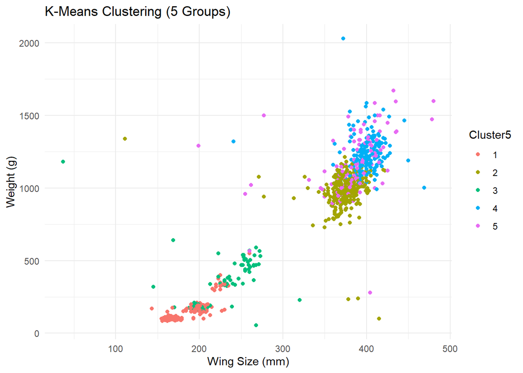

```r
ggplot(hawks_limpio2, aes(x = Wing, y = Weight, color = Cluster5)) +
  geom_point() +
  labs(title = "K-Means Clustering (5 Groups)",
       x = "Wing Size (mm)",
       y = "Weight (g)") +
  theme_minimal()
```

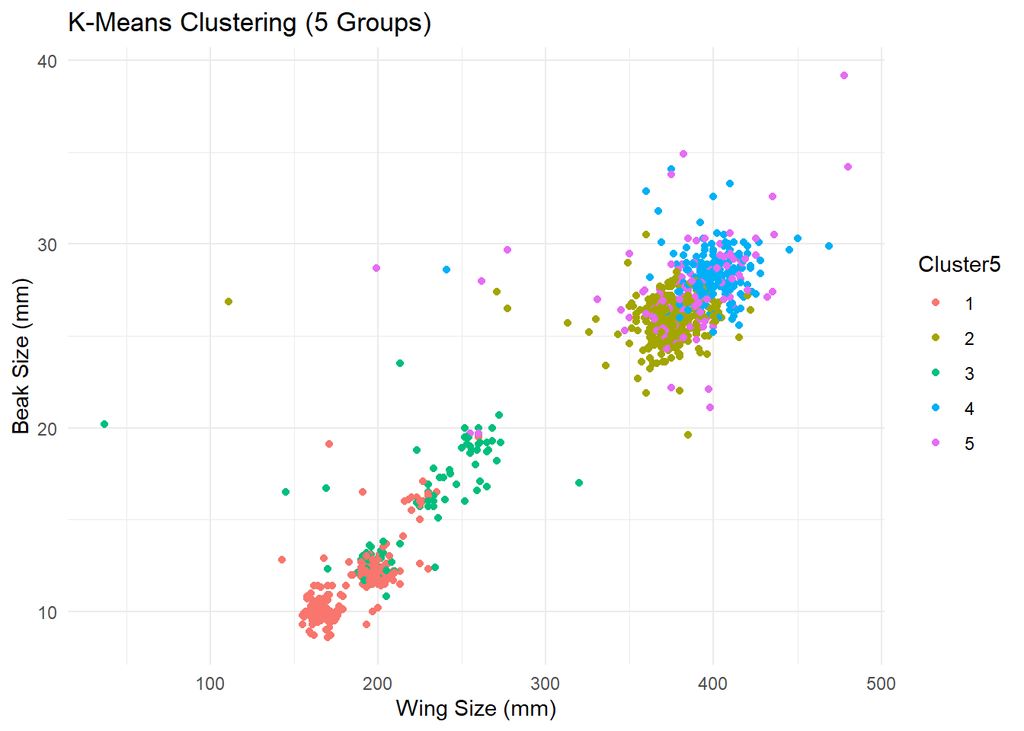

```r
ggplot(hawks_limpio2, aes(x = Wing, y = Culmen, color = Cluster5)) +
  geom_point() +
  labs(title = "K-Means Clustering (5 Groups)",
       x = "Wing Size (mm)",
       y = "Beak Size (mm)") +
  theme_minimal()
```

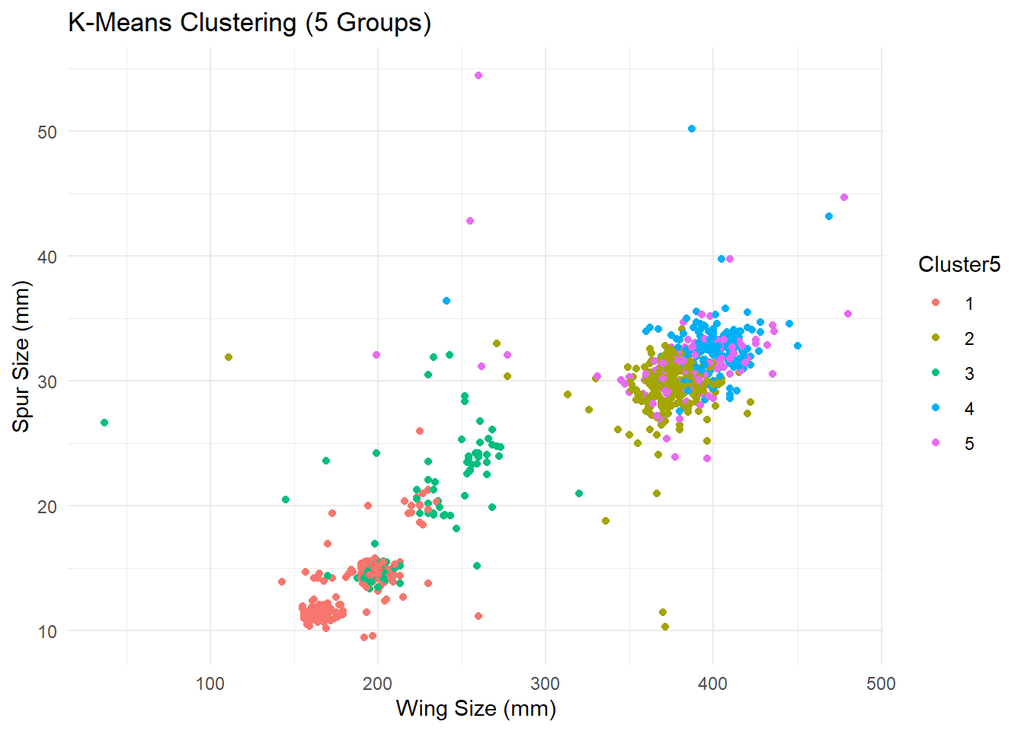

```r
ggplot(hawks_limpio2, aes(x = Wing, y = Hallux, color = Cluster5)) +
  geom_point() +
  labs(title = "K-Means Clustering (5 Groups)",
       x = "Wing Size (mm)",
       y = "Spur Size (mm)") +
  theme_minimal()
```

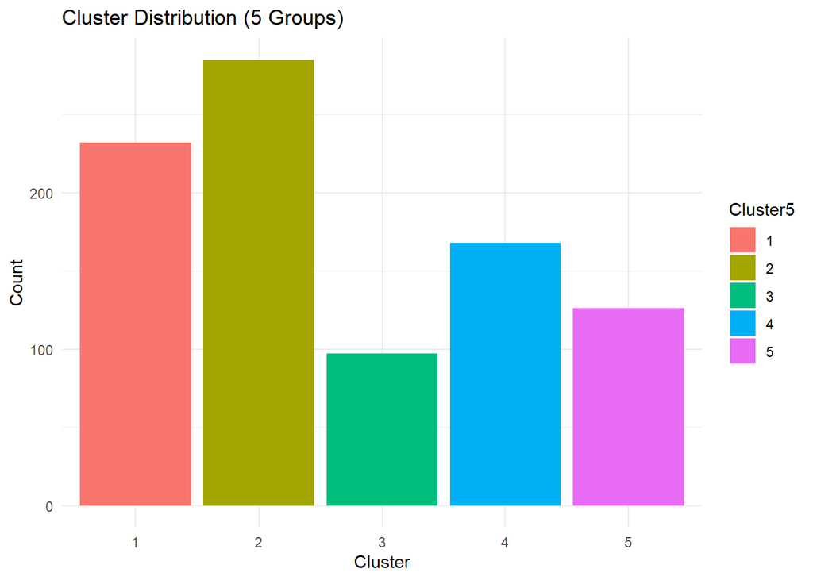

```r
ggplot(hawks_limpio2, aes(x = Cluster5, fill = Cluster5)) +
  geom_bar() +
  labs(title = "Cluster Distribution (5 Groups)",
       x = "Cluster",
       y = "Count") +
  theme_minimal()
```

We **clearly observe** that **5 clusters** is **too many**.

Although there is **no exact definition** of the **optimal number of clusters** to distinguish **significant differences** among the selected variables, we will apply **several methods** taught in the **Multivariate Analysis course** from previous semesters.

These methods include:  
- **Elbow Method**  
- **Silhouette Method**  
- **Gap Statistic**

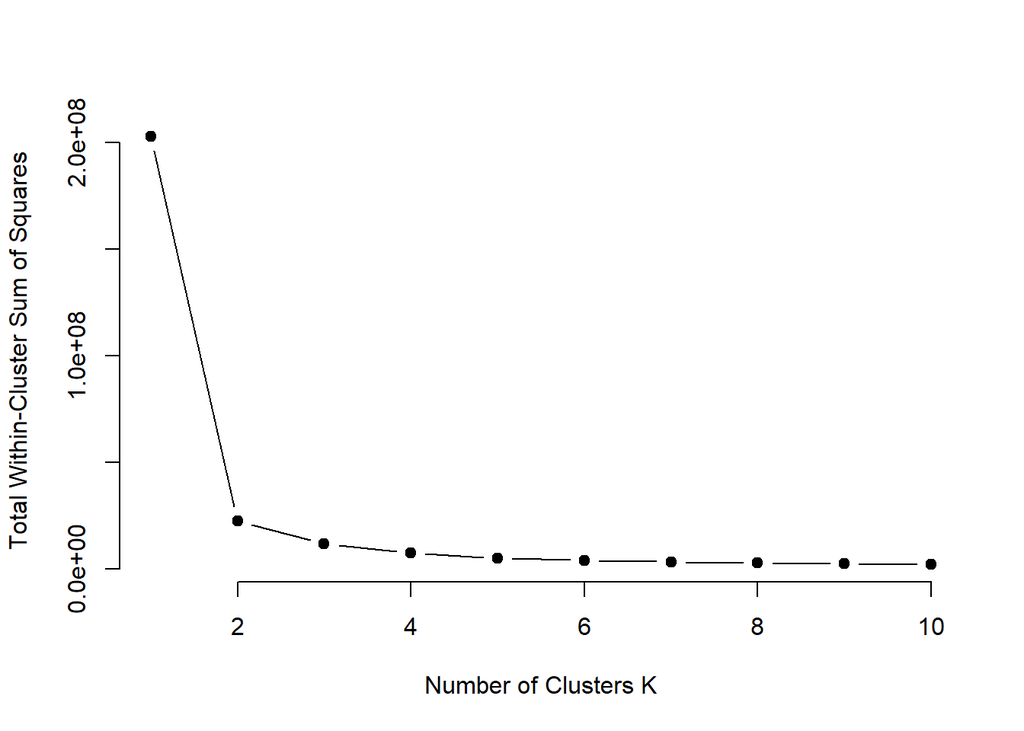

```r
dfnumeric <- hawks_limpio2 %>%
  select(Wing, Weight, Culmen, Hallux, Sex_M, Sex_F, Age_A, Age_I)

# Elbow Method
wss <- sapply(1:10, function(k) {
  kmeans(dfnumeric, k, nstart = 10)$tot.withinss
})

plot(1:10, wss, type = "b", pch = 19, frame = FALSE,
     xlab = "Number of Clusters K", ylab = "Total Within-Cluster Sum of Squares")
```

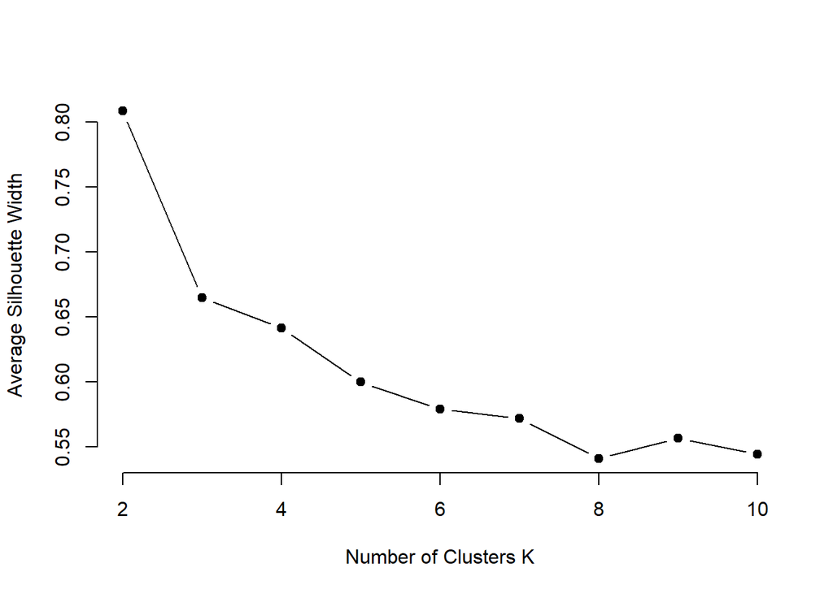

```r
# Silhouette Method
avg_sil <- sapply(2:10, function(k) {
  km <- kmeans(dfnumeric, centers = k, nstart = 10)
  ss <- silhouette(km$cluster, dist(dfnumeric))
  mean(ss[, 3])
})

plot(2:10, avg_sil, type = "b", pch = 19, frame = FALSE,
     xlab = "Number of Clusters K", ylab = "Average Silhouette Width")
```

```r
# Gap Statistic Method
gap_stat <- clusGap(dfnumeric, FUN = kmeans, nstart = 25, K.max = 10, B = 50)
```

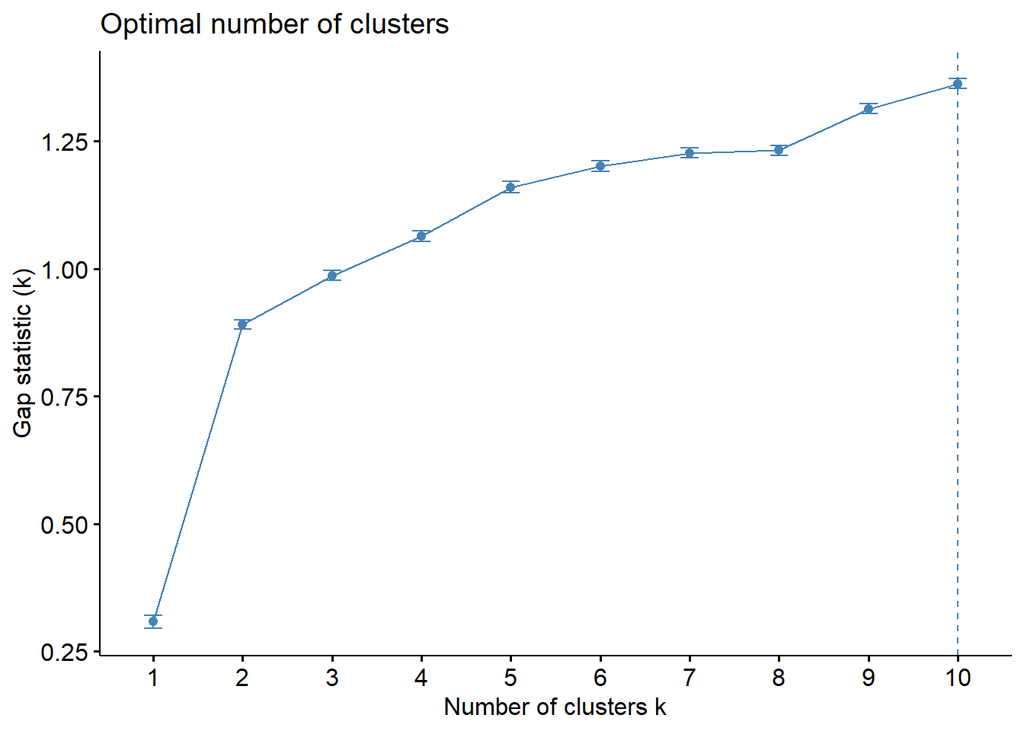

```r
fviz_gap_stat(gap_stat)
```

Finally, we create a **hierarchical clustering plot** using the selected **number of clusters: 3**.

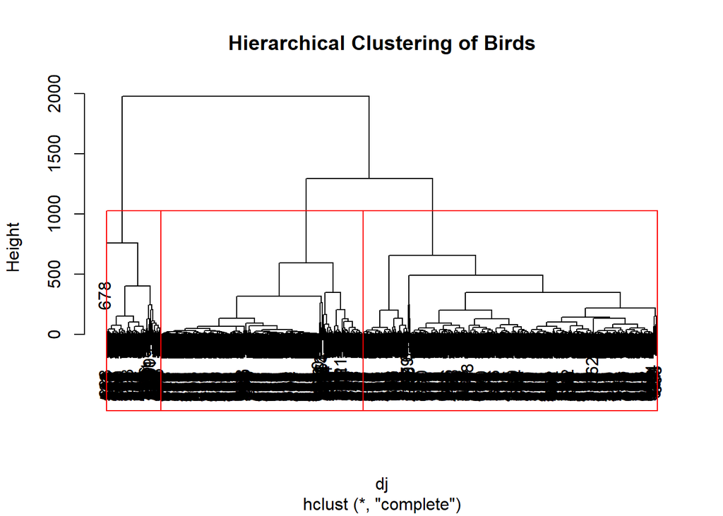

```r
dj <- dist(dfnumeric)
cc <- hclust(dj, method = "complete")
plot(cc, main = "Hierarchical Clustering of Birds")
rect.hclust(cc, k = 3, border = "red")
```

## Final Conclusions

As noted in our **initial exploratory analysis**, we have **more juvenile hawks compared to adults**, which may be a **key factor** influencing the **cluster distribution**.

The **number of species (3)** serves as a **key indicator** for selecting **3 clusters**.

However, much of our analysis also suggests that **2 clusters would not be an incorrect choice**.